# Rmarkdown: Climate change drives loss of bacterial gut mutualists at expense of host survival in wild meerkats

Alice Risely

16/09/2022

## 0.1 Load packages

```r
library(phyloseq)
library(ggord)
library(ggplot2)
library(viridis)
library(mgcViz)
library(dichromat)
library(ggpattern)
library(expss)
library(dplyr)
library(tidyverse)
library(GGally)
library(vegan)
library(ggpubr)
library(pheatmap)
library(lubridate)
library(ggsci)
library(RColorBrewer)
library(microbiome)
library(vegan)
library(lme4)
library(performance)
library(ggrepel)
library(zoo)

library(glmmTMB)
library(mgcv)
library(gratia)
library(speedyseq)
library(ggeffects)
library(MuMIn)
library(effects)
library(broom)
library(cowplot)
library(patchwork)

library("coxme")
library(survival)

library(SpiecEasi)
library(NetCoMi)

library(gllvm)
library(data.table)
library(datawizard)
library(ggcorrplot)
library(ggthemes)

memory.limit(1000000)
```

```
## [1] 1e+06
```

This chunk took 0.2 minutes

# 1 Data Import

```r
meerkat_final<-readRDS("C:\\Users\\risel\\Dropbox\\Sommer postdoc\\Meerkat project\\PROJECTS\\MeerkatSpikeInData\\Analysis updated\\6. TB AND MB POPULATION LEVEL\\Published data and code\\V2\\meerkat_MB_GCB.RDS")

daily_rainfall_merged <- read.csv("C:/Users/risel/Dropbox/Sommer postdoc/Meerkat project/PROJECTS/MeerkatSpikeInData/Analysis updated/6. TB AND MB POPULATION LEVEL/Published data and code/V2/rainfall_data.csv", row.names=1)

daily_temp_merged <- read.csv("C:/Users/risel/Dropbox/Sommer postdoc/Meerkat project/PROJECTS/MeerkatSpikeInData/Analysis updated/6. TB AND MB POPULATION LEVEL/Published data and code/V2/maxtemp_data.csv", row.names=1)


TB_stage_df<- read.csv("C:/Users/risel/Dropbox/Sommer postdoc/Meerkat project/PROJECTS/MeerkatSpikeInData/Analysis updated/6. TB AND MB POPULATION LEVEL/Published data and code/V2/TB_data.csv", row.names=1)

daily_rainfall_merged$Date<-as.Date(daily_rainfall_merged$Date, "%Y-%m-%d")
daily_temp_merged$Date<-as.Date(daily_temp_merged$Date, "%Y-%m-%d")
TB_stage_df$Date<-as.Date(TB_stage_df$Date, "%Y-%m-%d")
```

This chunk took 0.03 minutes

# 2 Count normalisation

- Scale counts by spike in

```r
asv_table<-data.frame(meerkat_final@otu_table@.Data)
asv_table[1:5,1:5]
```

|  | Feature1 | Feature3 | Feature5 | Feature7 | Feature8 |
| --- | --- | --- | --- | --- | --- |
| 9fbdf378dab9e9eb08dd9a40242519ce | 0 | 0 | 0 | 0 | 0 |
| bcf30d493845e88c18ee4926a7faadcf | 0 | 0 | 0 | 0 | 0 |
| 39201b436210bb1cab595417ba47c988 | 0 | 0 | 0 | 0 | 0 |
| 2f0074357586c801697a5914e6b555c4 | 0 | 0 | 0 | 0 | 0 |
| 691692c75df1f2b191b3c26eee12693a | 0 | 0 | 0 | 0 | 0 |

```r
names(asv_table)<-sample_data(meerkat_final)$feature.id
meerkat_normalized<-sweep(asv_table, MARGIN=2, sample_data(meerkat_final)$scaling_factor, `*`)
meerkat_normalized<-round(meerkat_normalized, digits = 0)
meerkat_normalized<-otu_table(meerkat_normalized, taxa_are_rows = TRUE)
meerkat_scaled<-meerkat_final
otu_table(meerkat_scaled)<-meerkat_normalized


### add total abundance of reads to dataframe
sample_data(meerkat_scaled)$TotalAbundance<-sample_sums(meerkat_scaled)

#Filter samples

#meerkat_filtered<-subset_samples(meerkat_scaled, Seq_depth_nospikein >3000)
meerkat_filtered<-subset_samples(meerkat_scaled, sample_sums(meerkat_scaled)>1000)
```

This chunk took 0.17 minutes

# 3 Fig. 1: Population and sample trends

```r
### left panel ###

p1<-ggplot(subset(daily_rainfall_merged, Date > "1996-01-01"), aes(x = Date, y = RollMean12Month_NOAA))+
  geom_point(size =0.1, aes(col = Col))+
  #geom_path(size =0.1)+
  geom_hline(yintercept = mean(daily_rainfall_merged$RollMean12Month_NOAA, na.rm = T), linetype = "longdash")+
 # ggtitle("VZ/KRC data")+
  theme_classic(base_size = 12)+
  ylab("Rainfall (mm)")+
  theme(legend.position = "none")+
  xlim(c(as.Date("1997-01-01"), as.Date("2020-01-01")))+
  theme(panel.grid.major.x = element_line(color = "grey",size = 0.5, linetype = 2))+
 theme(axis.title.x = element_blank())+
  scale_color_manual(values = c("dodgerblue3", "red"))+
  ggtitle("b)")+
  theme(plot.title = element_text( face = "bold", size = 13))



p2<-ggplot(subset(daily_temp_merged, Date > "1996-01-01"), aes(x = Date, y = RollMean12Month_curated))+
  geom_point(size =0.1, aes(col = Col))+
#  geom_path(size =0.1)+
  geom_hline(yintercept = mean(daily_temp_merged$RollMean12Month_curated, na.rm = T), linetype = "longdash")+
 # ggtitle("VZ/KRC data")+
  ylab("Max. temp. (°C)")+
  theme_classic(base_size = 12)+
  theme(legend.position = "none")+
  xlim(c(as.Date("1997-01-01"), as.Date("2020-01-01")))+
  theme(panel.grid.major.x = element_line(color = "grey",size = 0.5, linetype = 2))+
  theme(axis.title.x = element_blank())+
  scale_color_manual(values = c( "red", "dodgerblue3"))+
  ggtitle("a)")+
  theme(plot.title = element_text( face = "bold", size = 13))

p3<-ggplot(TB_stage_df, aes(x = Date, y = Proportion, col = TB_status))+
  geom_point(size = 0.1)+
  geom_path(size = 1)+
  scale_color_manual(values = c("forestgreen", "skyblue","brown2"))+
  theme_classic(base_size = 12)+
  ylab("Proportion population")+
 xlim(c(as.Date("1997-01-01"), as.Date("2020-01-01")))+
  theme(panel.grid.major.x = element_line(color = "grey",size = 0.5, linetype = 2))+
  theme(legend.position = c(0.17,0.5),
        legend.key.size = unit(0.05, "cm"),
        legend.key.width = unit(0.1, "cm"),
        legend.title = element_text(size = 10) )+
  labs(col = "TB status")+
  ggtitle("c)")+
  theme(plot.title = element_text( face = "bold", size = 13))



Fig1_left<-p2/p1/p3

## right panel ###
## right panel ###


meerkat_class<-tax_glom(meerkat_filtered, taxrank = "Class")

sample_data(meerkat_class)<-sample_data(meerkat_class)[,c("feature.id")]
meerkat_class<-microbiome::transform(meerkat_class, "compositional")
class_per_sample<-psmelt(meerkat_class)

top_class<-c("Bacteroidia","Fusobacteriia" ,  "Gammaproteobacteria", "Clostridia",
"Coriobacteriia","Actinobacteria",    "Bacilli")


class_per_sample$Class_plot<-as.character(ifelse(class_per_sample$Class %in% top_class, class_per_sample$Class, "Other"))

class_per_sample$Class_plot<-factor(class_per_sample$Class_plot, levels = c("Bacteroidia","Fusobacteriia" ,  "Other","Gammaproteobacteria", "Clostridia",
"Coriobacteriia","Actinobacteria",    "Bacilli"))


metadata<-data.frame(sample_data(meerkat_filtered))

metadata<-metadata[,c("feature.id", "SampleDate", "Year", "Storage", "HoursAfterSunrise", "TotalAbundance", "TB_stage", "Season", "Mean_maxtemp_3month",  "Mean_maxtemp_12month","Mean_rainfall_12month_NOAA", "Mean_rainfall_3month_NOAA", "Condition_weight", "GroupAtSampling", "AgeAtSampling")]

class_per_sample<- merge(class_per_sample, metadata, by = "feature.id")

## microbiome plot ######
## microbiome plot ######


pal<-brewer.pal(10,"Paired")
pal<-c(pal, "lightgrey")
pal<-pal[c(2,1,11,4,3,6,9,10)]
pal<-rev(pal)


plot_per_sample<-ggplot(class_per_sample, aes(y = Abundance, x = reorder(Sample, SampleDate), fill = Class_plot))+
  geom_col(position = "fill", stat="identity",  col = NA, width = 2)+
  scale_fill_manual(values = rev(pal))+
  ylab("Relative abundance")+
  theme(axis.text.x = element_blank(), axis.ticks = element_blank(), axis.title.x = element_blank())+
   scale_y_continuous(expand = c(0,0)) +
  labs(fill = "Bacterial class")+
   theme(plot.margin=unit(c(0.2,0.2,0.2,1),"cm"))+
  theme(legend.justification = c("left", "center"))



#### temp max ###
#### temp max ###

pal_dichromat<-dichromat::colorschemes$BluetoOrange.12

pal_dichromat[12]<-"black"
pal_dichromat[11]<-"red"


plot_temp1<-ggplot(class_per_sample, aes(y = 1, x = reorder(Sample, SampleDate), fill = Mean_maxtemp_12month))+geom_tile()+
  theme_void()+
 scale_fill_gradientn(colours = pal_dichromat)+
  theme(legend.position="right", legend.direction="vertical",
         legend.justification = c("left", "top"),
        legend.key.height = unit(0.15, 'cm'),
        legend.title=element_blank(), legend.text=element_text(size=6)) +
  theme(axis.title.y = element_text(angle = 0))+
  ylab(" Max \ntemp")

### rainfall ######
### rainfall ######


plot_rainfall2<-ggplot(class_per_sample, aes(y = 1, x = reorder(Sample, SampleDate), fill = Mean_rainfall_12month_NOAA))+geom_tile()+
  theme_void()+
 scale_fill_gradientn(colours = rev(pal_dichromat[1:12]))+
   theme(legend.position="right", legend.direction="vertical",
        legend.justification = c("left", "top"),
        legend.key.height = unit(0.15, 'cm'),
        legend.title=element_blank(), legend.text=element_text(size=6))+
   theme(axis.title.y = element_text(angle = 0))+
  ylab("Rainfall")


## TB stage ###
## TB stage ###


levels(class_per_sample$TB_stage)
```

```
## [1] "Unexposed" "Exposed"   "Diseased"
```

```r
levels(class_per_sample$TB_stage)<-c("TB unexposed", "TB exposed", "TB diseased")
#levels(class_per_sample$TB_stage_weight)<-c("TB unexposed", "TB exposed", "TB diseased")

table(class_per_sample$TB_stage)
```

```
##
## TB unexposed   TB exposed  TB diseased
##        43363        64890         9270
```

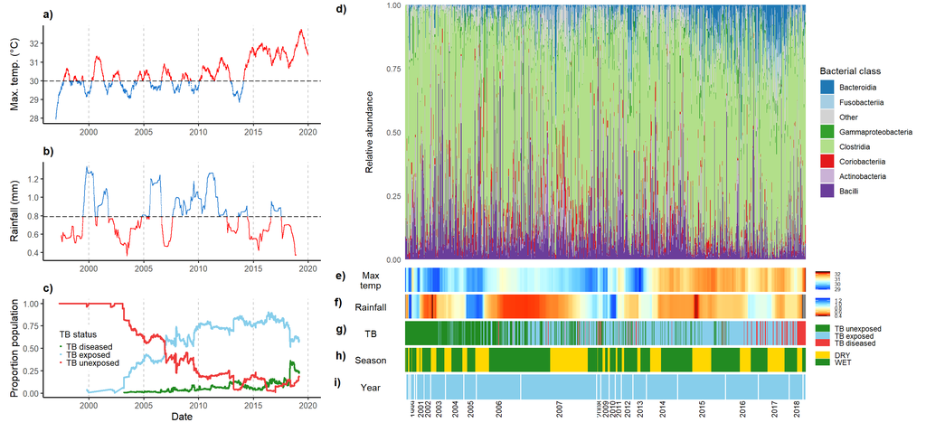

```r
plot_TB_sample<-ggplot(class_per_sample, aes(y = 1, x = reorder(Sample, SampleDate), fill = TB_stage))+
  geom_tile()+
  theme_void()+
scale_fill_manual(values = c( "forestgreen", "skyblue","brown2"))+
  theme(axis.title.y = element_text(angle = 0))+
  ylab("TB")+
  theme(legend.position="right", legend.direction="vertical",
       legend.justification = c("left", "top"),
        legend.key.height = unit(0.3, 'cm'),
        legend.title=element_blank())



## season ###
## season ###

plot_season<-ggplot(class_per_sample, aes(y = 1, x = reorder(Sample, SampleDate), fill = Season))+
  geom_tile()+
  theme_void()+
  scale_fill_manual(values = c("gold", "forestgreen"))+
  theme(legend.position="right", legend.direction="vertical",
        legend.justification = c("left", "top"),
        legend.key.height = unit(0.1, 'cm'),
        legend.title=element_blank())+
   theme(axis.title.y = element_text(angle = 0))+
  ylab("Season")


# year labels ###
# year labels ###

year_names <- c(
                    `1997` = "",
                    `1998` = "",
                    `1999` = "1999",
                    `2000` = "",
                    `2001` = "2001",
                    `2002` = "2002",
                    `2003` = "2003",
                    `2004` = "2004",
                    `2005` = "2005",
                    `2006` = "2006",
                    `2007` = "2007",
                    `2008` = "2008",
                    `2009` = "2009",
                    `2010` = "2010",
                    `2011` = "2011",
                    `2012` = "2012",
                    `2013` = "2013",
                    `2014` = "2014",
                    `2015` = "2015",
                    `2016` = "2016",
                    `2017` = "2017",
                    `2018` = "2018",
                    `2019` = "")

##### year ######
##### year ######
##### year ######

plot_year<-ggplot(class_per_sample, aes(y = 1, x = reorder(Sample, SampleDate)))+
  geom_tile(fill = "skyblue")+
  theme_void()+
 # scale_fill_viridis(discrete = F)+
  #scale_fill_manual(values = c("red", "skyblue"))+
  facet_grid(~Year, scales = "free", space = "free_x",switch = "x", labeller = as_labeller(year_names))+

  theme(panel.spacing = unit(0.07, "lines"),
         strip.background = element_blank(),
         strip.placement = "outside",
         strip.text.x = element_text(angle = 90, hjust = 0.5)) +

   xlab("")+
    theme(axis.title.y = element_text(angle = 0, hjust = ))+
  ylab("Year          ")+
  theme(axis.title.x = element_text(colour = "black"))+
  theme(plot.margin=unit(c(0,4.95,0.2,1.25),"cm")) +
    theme(legend.position="right", legend.direction="vertical",
        legend.justification = c("left", "top"),
        legend.key.height = unit(0.2, 'cm'),
        legend.title=element_blank())

## put it all together


sup_figabc<-ggarrange(plot_per_sample, plot_temp1,plot_rainfall2, plot_TB_sample,  plot_season,
                      ncol = 1, align = "v", heights = c(10,1,1, 1,  1),
                      labels= c("d)", "e)", "f)", "g)", "h)"),
                      font.label = list(size = 13))

Fig1_right<-ggarrange(sup_figabc, plot_year, ncol = 1, heights = c(7,1.1),
                      labels = c(NA, "i)"), font.label = list(size = 13))



# fig 1
ggarrange(Fig1_left, Fig1_right, ncol = 2, widths = c(1,1.8))
```

This chunk took 0.42 minutes

# 4 Fig 2: Constrained ordination

```r
scaled_core<-microbiome::core(meerkat_filtered, detection = 100, prevalence = 0.01)
#scaled_core <-microbiome::transform(scaled_core, transform = "clr")
```

This chunk took 0.02 minutes

- Generate distance matrices

```r
###### genus level

wunifrac_dist<-distance(scaled_core, method = "wunifrac")
```

This chunk took 4.3 minutes

- organise variables

```r
otutable<-data.frame(t(scaled_core@otu_table@.Data))
dim(otutable)
```

```
## [1] 1141  614
```

```r
otutable[1:5,1:5]
```

|  | X997102f8afa158a7d8d67bcff542e9f1 | a6324500829bbbc3ed1e0303d0edda77 | X3d863893c4978f1c06f1ab1e48e99617 | f6fbbb88269a4e8f4f2cdd09a807b75b | f5236f96db38a1fdf4db6aa762c613fb |
| --- | --- | --- | --- | --- | --- |
| Feature1 | 0 | 0 | 0 | 0 | 0 |
| Feature3 | 0 | 0 | 14 | 0 | 0 |
| Feature5 | 0 | 0 | 0 | 0 | 0 |
| Feature7 | 0 | 0 | 0 | 0 | 0 |
| Feature8 | 0 | 15 | 42 | 0 | 0 |

```r
colnames(otutable)<-taxa_names(scaled_core)

metadata<-data.frame(sample_data(scaled_core))

time<-metadata$TimeCat
year<-metadata$Year

# methods
storage<-metadata$Storage
seq_depth<-as.numeric(scale(metadata$Seq_depth_nospikein))
seq_run<-metadata$Seq_run
```

This chunk took 0 minutes

- Apply constrained ordination models (dbRDA)

```r
# weighted unifrac

wu_model<-capscale(wunifrac_dist ~ time+
                             year + storage,
                env = metadata, comm = otutable)


final_model_anova<-anova.cca(wu_model, by="terms")
final_model_anova
```

|  | Df | SumOfSqs | F | Pr(>F) |
| --- | --- | --- | --- | --- |
| time | 1 | 6.4556307 | 74.287572 | 0.001 |
| year | 1 | 2.2469710 | 25.856810 | 0.001 |
| storage | 1 | 0.2080328 | 2.393918 | 0.007 |
| Residual | 1137 | 98.8059226 | NA | NA |

This chunk took 0.28 minutes

- Oridination figure

```r
######################################

## extract data from model

wu_model_df<-scores(wu_model)
str(wu_model_df)
```

```
## List of 3
##  $ species  : num [1:614, 1:2] -0.000766 -0.030216 -0.014545 0.000488 0.002044 ...
##   ..- attr(*, "dimnames")=List of 2
##   .. ..$ : chr [1:614] "997102f8afa158a7d8d67bcff542e9f1" "a6324500829bbbc3ed1e0303d0edda77" "3d863893c4978f1c06f1ab1e48e99617" "f6fbbb88269a4e8f4f2cdd09a807b75b" ...
##   .. ..$ : chr [1:2] "CAP1" "CAP2"
##  $ sites    : num [1:1141, 1:2] -0.565 -0.164 -0.802 1.457 0.538 ...
##   ..- attr(*, "dimnames")=List of 2
##   .. ..$ : chr [1:1141] "Feature1" "Feature3" "Feature5" "Feature7" ...
##   .. ..$ : chr [1:2] "CAP1" "CAP2"
##  $ centroids: num [1:4, 1:2] 0.694 -0.355 -0.136 0.19 -0.213 ...
##   ..- attr(*, "dimnames")=List of 2
##   .. ..$ : chr [1:4] "timeAFTERNOON" "timeMORNING" "storageFREEZEDRIED" "storageFROZEN"
##   .. ..$ : chr [1:2] "CAP1" "CAP2"
##  - attr(*, "const")= num 17.5
```

```r
# extract CAP scores

vectors_df<-data.frame(wu_model_df$sites)

vectors_df$feature.id<-row.names(vectors_df)

cap_values_df<-vectors_df

# merge with info on dominant family

sample_metadata<-data.frame(sample_data(scaled_core))
vectors_df<-merge(vectors_df, sample_metadata, by = "feature.id")

sample_data(meerkat_filtered)[1:5,1]
```

```
## Error in validObject(.Object): invalid class "sample_data" object: Sample Data must have non-zero dimensions.
```

```r
sample_data(meerkat_final)[1:5,1]
```

```
## Error in validObject(.Object): invalid class "sample_data" object: Sample Data must have non-zero dimensions.
```

```r
cap_values_df[1:5,]
```

|  | CAP1 | CAP2 | feature.id |
| --- | --- | --- | --- |
| Feature1 | -0.5651689 | 1.4649379 | Feature1 |
| Feature3 | -0.1642000 | -0.4693233 | Feature3 |
| Feature5 | -0.8024147 | 2.5139687 | Feature5 |
| Feature7 | 1.4570193 | -0.4629558 | Feature7 |
| Feature8 | 0.5378537 | -0.4741544 | Feature8 |

```r
sample_data(meerkat_filtered)[20:25,1]
```

```
## Error in validObject(.Object): invalid class "sample_data" object: Sample Data must have non-zero dimensions.
```

```r
sample_data(meerkat_final)[20:25,1]
```

```
## Error in validObject(.Object): invalid class "sample_data" object: Sample Data must have non-zero dimensions.
```

```r
cap_values_df[20:25,]
```

|  | CAP1 | CAP2 | feature.id |
| --- | --- | --- | --- |
| Feature25 | -1.0177180 | 2.6484076 | Feature25 |
| Feature26 | 0.3381284 | 0.5750681 | Feature26 |
| Feature27 | -0.7203103 | 2.4757347 | Feature27 |
| Feature28 | -0.6669268 | 2.3368972 | Feature28 |
| Feature29 | -0.4332400 | 2.1769824 | Feature29 |
| Feature30 | -0.4255937 | 1.5269431 | Feature30 |

```r
sample_data(meerkat_filtered)$CAP1<-cap_values_df$CAP1
sample_data(meerkat_filtered)$CAP2<-cap_values_df$CAP2

#########################

p_beta1<-ggplot(vectors_df, aes(x = CAP1, y = CAP2))+
  stat_ellipse(geom = "polygon", aes(fill = YearCat, col = YearCat), level = 0.9, alpha = 0.2, size = 0.5)+
  geom_point(aes(fill =YearCat), pch = 21, size = 1.5, col = "black")+
  theme_classic(base_size = 12)+
   scale_fill_viridis(discrete = TRUE, direction = -1)+scale_color_viridis(discrete = TRUE, direction = -1)+
  labs(fill = "Period", col = "Period")+
 geom_point(data = subset(vectors_df, YearCat == "Pre-2005"), pch = 21, size = 1.5, col = "black", fill = "yellow")+
  theme(legend.position = c(0.85,0.9))+
  theme(legend.key.size = unit(0.2, "cm"),
        legend.title = element_blank())


vectors_df$TimeCat<-ifelse(vectors_df$TimeCat == "MORNING", "Morning", "Afternoon")
vectors_df$TimeCat<-factor(vectors_df$TimeCat, levels = c("Morning", "Afternoon"))

p_beta3<-ggplot(vectors_df, aes(x = CAP1, y = CAP2))+
  stat_ellipse(geom = "polygon", aes(fill = TimeCat, col = TimeCat), level = 0.9, alpha = 0.2, size = 0.5)+
  geom_point(aes(fill =TimeCat), pch = 21, size = 1.5,  col = "black")+
  theme_classic(base_size = 12)+
   scale_fill_manual(values = c("skyblue", "red"))+
   scale_color_manual(values = c( "skyblue", "red"))+
  labs(fill = "Time", col = "Time")+
  theme(legend.position = c(0.9,0.9))+
  theme(legend.key.size = unit(0.2, "cm"),
        legend.title = element_blank())



p_beta2<-ggplot(vectors_df, aes(x = YearCat, y = CAP2, fill = YearCat, col = YearCat))+
  geom_jitter(alpha =0.4, width = 0.2,  pch = 21, size = 0.5)+
  geom_boxplot( pch = 21, size = 0.5, col = "black")+
   scale_fill_viridis(discrete = TRUE, direction = -1)+
 scale_color_viridis(discrete = TRUE, direction = -1)+
  theme_classic(base_size = 12)+
  labs(fill = "Period", col = "Period")+
    theme(axis.text.x = element_text(angle = 45, vjust = 1, hjust=1))+
  theme(axis.title.x = element_blank())+
theme(legend.position = "none")


# model CAP2 scores

beta_model<-lmer(CAP2~YearCat +(1|IndividID), data = vectors_df) #gaussian

summary(beta_model)
```

```
## Linear mixed model fit by REML ['lmerMod']
## Formula: CAP2 ~ YearCat + (1 | IndividID)
##    Data: vectors_df
##
## REML criterion at convergence: 3876.6
##
## Scaled residuals:
##      Min       1Q   Median       3Q      Max
## -2.70792 -0.68175 -0.03437  0.71460  2.64881
##
## Random effects:
##  Groups    Name        Variance Std.Dev.
##  IndividID (Intercept) 0.00421  0.06489
##  Residual              1.73272  1.31633
## Number of obs: 1141, groups:  IndividID, 235
##
## Fixed effects:
##                  Estimate Std. Error t value
## (Intercept)        1.0659     0.1077   9.896
## YearCat2005-2010  -0.9128     0.1253  -7.286
## YearCat2010-2015  -1.1178     0.1439  -7.768
## YearCat2015-2019  -1.6488     0.1277 -12.912
##
## Correlation of Fixed Effects:
##             (Intr) YC2005 YC2010
## YC2005-2010 -0.858
## YC2010-2015 -0.748  0.643
## YC2015-2019 -0.844  0.724  0.633
```

```r
sjPlot::tab_model(beta_model)
```

|  | CAP2 |  |  |
| --- | --- | --- | --- |
| Predictors | Estimates | CI | p |
| (Intercept) | 1.07 | 0.85 – 1.28 | **<0.001** |
| YearCat2005-2010 | -0.91 | -1.16 – -0.67 | **<0.001** |
| YearCat2010-2015 | -1.12 | -1.40 – -0.84 | **<0.001** |
| YearCat2015-2019 | -1.65 | -1.90 – -1.40 | **<0.001** |
| Random Effects |  |  |  |
| σ<sup>2</sup> | 1.73 |  |  |
| τ<sub>00</sub> <sub>IndividID</sub> | 0.00 |  |  |
| ICC | 0.00 |  |  |
| N <sub>IndividID</sub> | 235 |  |  |
| Observations | 1141 |  |  |
| Marginal R<sup>2</sup> / Conditional R<sup>2</sup> | 0.135 / 0.137 |  |  |

```r
# ICC value
icc(beta_model)
```

```
## # Intraclass Correlation Coefficient
##
##     Adjusted ICC: 0.002
##   Unadjusted ICC: 0.002
```

This chunk took 0.1 minutes

- Microbiome composition by year barplot

```r
meerkat_merged_year<-merge_samples(meerkat_filtered,"Year", fun=mean)

sample_data(meerkat_merged_year)$Year<-sample_names(meerkat_merged_year)

meerkat_merged_year_class<-tax_glom(meerkat_merged_year, taxrank = "Class")

sample_data(meerkat_merged_year_class)<-sample_data(meerkat_merged_year_class)[,1]

class_per_year<-psmelt(meerkat_merged_year_class)


class_per_year$Class_plot<-as.character(ifelse(class_per_year$Class %in% top_class, class_per_year$Class, "Other"))

class_per_year$Class_plot<-factor(class_per_year$Class_plot, levels = c("Bacteroidia","Fusobacteriia" ,  "Other","Gammaproteobacteria", "Clostridia",
"Coriobacteriia","Actinobacteria",    "Bacilli"))

class_per_year$Sample<- as.integer(class_per_year$Sample)

class_per_year<-class_per_year%>% group_by(Sample, Class_plot)%>%summarize(Abundance = sum(Abundance))
class_per_year<-data.frame(class_per_year)
class_per_year$Sample<-factor(class_per_year$Sample)

plot_mb_year<-ggplot(class_per_year, aes(x =Sample, y = Abundance, fill = Class_plot))+
  geom_bar( stat="identity",  size = 0, position = "fill")+
   theme_classic(base_size = 12)+
  scale_fill_manual(values = rev(pal))+
  theme(legend.position = "right")+
  xlab("")+
  theme(axis.text.x = element_text(angle = 90, vjust = 0.9, hjust=1))+
     theme(axis.text.y = element_text(size=8))+
  labs(fill = "Bacterial class")+
   scale_y_continuous(expand = c(0,0))+
  xlab("Year")+
  theme(legend.text = element_text(size=8),
  legend.title = element_text(size=10))+
  theme(legend.key.height = unit(0.3,'cm'))+
  theme(legend.key.width = unit(0.3,'cm'))+
  theme(axis.text.x = element_text(size = 8))+
  theme(plot.margin=unit(c(0,0.2,0.2,0.2),"cm"))

##############
##############
##############

year_freq<-data.frame(table(sample_data(meerkat_filtered)$Year))
names(year_freq)[1]<-"Year"

year_freq$Year<-as.numeric(as.character(year_freq$Year))

year_freq<-year_freq %>% mutate(YearCat = case_when((Year <2005 ~ "Pre-2005"),
                                                  (Year >=2005 & Year < 2010) ~ "2005-2010",
                                                  (Year >=2010 & Year < 2015) ~ "2010-2015",
                                                  (Year >=2015) ~ "2015-2019"))

year_freq$YearCat<-factor(year_freq$YearCat, levels = c("Pre-2005", "2005-2010", "2010-2015", "2015-2019"))


year_freq$Year<-factor(year_freq$Year)

#######
#######
#######


year_hist<-ggplot(year_freq, aes(x = Year, y = Freq, fill = YearCat)) +
   geom_bar( stat = "identity", size = 0)+
# theme(plot.margin=unit(c(0.2,5,0.2,0.2),"cm"))+
  theme(axis.text.x = element_blank(), axis.title.x = element_blank())+
  theme(legend.position = "right")+
  scale_y_sqrt(breaks = c(0,20,50,100,200))+
 # geom_hline(yintercept = 20, col = "black", linetype = "longdash")+
     scale_fill_viridis(discrete = TRUE, direction = -1)+
 scale_color_viridis(discrete = TRUE, direction = -1)+
    theme(legend.key.height = unit(0.1, 'cm'),
          legend.title = element_blank())+
   theme(legend.text = element_text(size=8))+
   theme(axis.text.y = element_text(size=6))+
  theme(plot.margin=unit(c(0.2,0.2,0,0.2),"cm"))

year_plot<-ggarrange(year_hist, plot_mb_year, ncol = 1, align = "v", heights = c(1,4))+theme(plot.margin=unit(c(0.2,0.2,0.2,0.4),"cm"))
```

This chunk took 0.07 minutes

- Ordination by individual ID

```r
meerkat_merged_ID<-merge_samples(meerkat_filtered,"IndividID", fun=mean)
sample_data(meerkat_merged_ID)$IndividID<-sample_names(meerkat_merged_ID)
sample_data(meerkat_merged_ID)<-sample_data(meerkat_merged_ID)[,2]

scaled_core_id<-microbiome::core(meerkat_merged_ID, detection = 100, prevalence = 0.01)

wunifrac_dist_id<-distance(scaled_core_id, method = "wunifrac")

############

otutable<-data.frame(scaled_core_id@otu_table@.Data)
dim(otutable)
```

```
## [1]  235 1348
```

```r
otutable[1:5,1:5]
```

|  | a29558bc215cfe6f913afafef02450b9 | de14e4fbd65f5ea24336f74fca93998d | eb5e72c0f85766e6bd0130723b04144c | e57c5df6a9b3b982472e7754ed31f313 | X4608fae4bbc9964cdd17af8782f2155e |
| --- | --- | --- | --- | --- | --- |
| ID 1 | 0 | 0 | 0 | 0 | 0 |
| ID 10 | 0 | 0 | 0 | 0 | 0 |
| ID 100 | 0 | 0 | 0 | 0 | 0 |
| ID 101 | 0 | 0 | 0 | 0 | 0 |
| ID 102 | 0 | 0 | 0 | 0 | 0 |

```r
colnames(otutable)<-taxa_names(scaled_core_id)

metadata<-data.frame(sample_data(scaled_core_id))
metadata_original<- data.frame(sample_data(meerkat_filtered))
metadata$BirthDate<-vlookup(metadata$IndividID, metadata_original, lookup_column = "IndividID", result_column = "BirthDate")
metadata$BirthYear<-lubridate::year(metadata$BirthDate)

metadata<-metadata%>% mutate(YearCat = case_when((BirthYear <2005 ~ "Pre-2005"),
                                                  (BirthYear >=2005 & BirthYear < 2010) ~ "2005-2010",
                                                  (BirthYear >=2010 & BirthYear < 2015) ~ "2010-2015",
                                                  (BirthYear >=2015) ~ "2015-2019"))

metadata$YearCat<-factor(metadata$YearCat, levels = c("Pre-2005", "2005-2010", "2010-2015", "2015-2019"))


# year


YearCat<-as.character(metadata$YearCat)
year<-metadata$BirthYear
table(metadata$YearCat)
```

```
##
##  Pre-2005 2005-2010 2010-2015 2015-2019
##        52        73        72        38
```

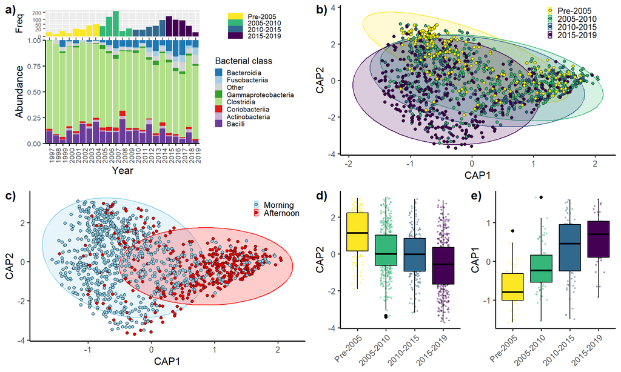

```r
id_model<-capscale(wunifrac_dist_id ~
                             year,
                env = metadata, comm = otutable)

## extract data from model

final_model_df<-scores(id_model)

# extract CAP scores

vectors_df_id<-data.frame(final_model_df$sites)

vectors_df_id$feature.id<-row.names(vectors_df_id)

# merge with info on dominant family

vectors_df_id<-merge(vectors_df_id, metadata, by.x = "feature.id", by.y = "IndividID")

############
############
############


#########################



beta_id<-ggplot(vectors_df_id, aes(x = YearCat, y = CAP1, fill = YearCat, col = YearCat))+
  geom_jitter(alpha =0.4, width = 0.2,  pch = 21, size = 0.5)+
  geom_boxplot( pch = 21, size = 0.5, col = "black")+
   scale_fill_viridis(discrete = TRUE, direction = -1)+
 scale_color_viridis(discrete = TRUE, direction = -1)+
  theme_classic(base_size = 12)+
  labs(fill = "Period", col = "Period")+
    theme(axis.text.x = element_text(angle = 45, vjust = 1, hjust=1))+
  theme(axis.title.x = element_blank())+
theme(legend.position = "none")



p1<-ggarrange(year_plot, p_beta1, ncol = 2,  labels = c("a)", "b)"))
p2<-ggarrange(p_beta3, p_beta2, beta_id, ncol = 3,  widths = c(2,1,1), labels = c("c)", "d)", "e)"))

ggarrange(p1, p2, nrow = 2)
```

This chunk took 0.33 minutes

# 5 Fig. 3: GAMs and non-linear trends

```r
meerkat_genus<-microbiome::aggregate_top_taxa(meerkat_filtered, "Genus", top = 50)
clr_scaled <-microbiome::transform(meerkat_genus, transform = "clr")


taxa_to_keep <- c("[Ruminococcus] torques group" , "Arthrobacter", "Bacillus","Bacteroides",
 "Blautia", "Catenisphaera" ,"Christensenellaceae R-7 group", "Clostridium sensu stricto 1",
"Collinsella" ,"Enterococcus" , "Escherichia-Shigella","Fusobacterium",
"Geodermatophilus","Lachnoclostridium", "Lactococcus" ,"Marvinbryantia" ,
"Paeniclostridium","Peptoclostridium" , "Peptococcus" ,"Phascolarctobacterium",
"Romboutsia", "Slackia" ,"Turicibacter" , "Weissella" ,
"Rikenellaceae RC9 gut group", "Helicobacter" , "Parabacteroides", "Lactobacillus",
 "Pediococcus", "Streptococcus" )

#meerkat_genus<-microbiome::aggregate_top_taxa(meerkat_filtered, "Genus", top = 50)

#meerkat_genus_scaled<-prune_taxa(taxa_to_keep, meerkat_genus)
meerkat_genus_scaled<-prune_taxa(taxa_to_keep,clr_scaled) # new

genus_ps<-meerkat_genus_scaled
sample_data(genus_ps)<-sample_data(genus_ps)[,c( "feature.id")]

top_genera_melt<-psmelt(genus_ps)
head(top_genera_melt)
```

|  | OTU | Sample | Abundance | feature.id | Genus | unique |
| --- | --- | --- | --- | --- | --- | --- |
| 1 | Clostridium sensu stricto 1 | Feature96 | 9.732659 | Feature96 | Clostridium sensu stricto 1 | Clostridium sensu stricto 1 |
| 2 | Clostridium sensu stricto 1 | Feature273 | 9.684616 | Feature273 | Clostridium sensu stricto 1 | Clostridium sensu stricto 1 |
| 3 | Clostridium sensu stricto 1 | Feature360 | 9.673822 | Feature360 | Clostridium sensu stricto 1 | Clostridium sensu stricto 1 |
| 4 | Clostridium sensu stricto 1 | Feature492 | 9.537422 | Feature492 | Clostridium sensu stricto 1 | Clostridium sensu stricto 1 |
| 5 | Clostridium sensu stricto 1 | Feature295 | 9.491134 | Feature295 | Clostridium sensu stricto 1 | Clostridium sensu stricto 1 |
| 6 | Clostridium sensu stricto 1 | Feature345 | 9.416304 | Feature345 | Clostridium sensu stricto 1 | Clostridium sensu stricto 1 |

```r
metadata<-data.frame(sample_data(meerkat_genus_scaled))

top_genera_melt3<- merge(top_genera_melt, metadata, by.x = "Sample", by.y = "feature.id")
names(top_genera_melt3)
```

```
##  [1] "Sample"                     "OTU"
##  [3] "Abundance"                  "feature.id"
##  [5] "Genus"                      "unique"
##  [7] "IndividID"                  "SampleDate"
##  [9] "SampleTime"                 "Storage"
## [11] "Seq_run"                    "Imtechella"
## [13] "Allobacillus"               "Seq_depth"
## [15] "scaling_factor"             "Seq_depth_nospikein"
## [17] "BirthDate"                  "DeathDate"
## [19] "AgeAtSampling"              "GroupAtSampling"
## [21] "Condition_weight"           "SocialStatus"
## [23] "Temp_max"                   "sum_rainfall_month"
## [25] "HoursAfterSunrise"          "TimeCat"
## [27] "Year"                       "month"
## [29] "Season"                     "TB_status"
## [31] "TB_exposure"                "TB_resistance"
## [33] "TB_survival"                "TB_symptom_date"
## [35] "TB_exposure_date"           "TB_stage"
## [37] "YearCat"                    "Quarter"
## [39] "Mean_rainfall_1month"       "Mean_rainfall_3month"
## [41] "Mean_rainfall_6month"       "Mean_rainfall_12month"
## [43] "Mean_rainfall_1month_NOAA"  "Mean_rainfall_3month_NOAA"
## [45] "Mean_rainfall_6month_NOAA"  "Mean_rainfall_12month_NOAA"
## [47] "Mean_maxtemp_1month"        "Mean_maxtemp_3month"
## [49] "Mean_maxtemp_6month"        "Mean_maxtemp_12month"
## [51] "TotalAbundance"             "CAP1"
## [53] "CAP2"
```

```r
head(top_genera_melt3)
```

|  | Sample | OTU | Abundance | feature.id | Genus | unique | IndividID | SampleDate | SampleTime | Storage | Seq_run | Imtechella | Allobacillus | Seq_depth | scaling_factor | Seq_depth_nospikein | BirthDate | DeathDate | AgeAtSampling | GroupAtSampling | Condition_weight | SocialStatus | Temp_max | sum_rainfall_month | HoursAfterSunrise | TimeCat | Year | month | Season | … |
| --- | --- | --- | --- | --- | --- | --- | --- | --- | --- | --- | --- | --- | --- | --- | --- | --- | --- | --- | --- | --- | --- | --- | --- | --- | --- | --- | --- | --- | --- | --- |
| 1 | Feature1 | Weissella | -2.120013 | Feature1 | Weissella | Weissella | ID 69 | 1997-04-18 | 1899-12-30 07:29:00 | FROZEN | RUN1 | 247 | 331 | 27482 | 4.769479 | 26904 | 1997-03-03 | 2003-12-08 | 46 | Vivian | -101.9367 | Subordinate | 32.7 | 25.4 | 1.545278 | MORNING | 1997 | 4 | WET | … |
| 2 | Feature1 | Blautia | 7.710587 | Feature1 | Blautia | Blautia | ID 69 | 1997-04-18 | 1899-12-30 07:29:00 | FROZEN | RUN1 | 247 | 331 | 27482 | 4.769479 | 26904 | 1997-03-03 | 2003-12-08 | 46 | Vivian | -101.9367 | Subordinate | 32.7 | 25.4 | 1.545278 | MORNING | 1997 | 4 | WET | … |
| 3 | Feature1 | Lactobacillus | -2.120013 | Feature1 | Lactobacillus | Lactobacillus | ID 69 | 1997-04-18 | 1899-12-30 07:29:00 | FROZEN | RUN1 | 247 | 331 | 27482 | 4.769479 | 26904 | 1997-03-03 | 2003-12-08 | 46 | Vivian | -101.9367 | Subordinate | 32.7 | 25.4 | 1.545278 | MORNING | 1997 | 4 | WET | … |
| 4 | Feature1 | Phascolarctobacterium | -2.120013 | Feature1 | Phascolarctobacterium | Phascolarctobacterium | ID 69 | 1997-04-18 | 1899-12-30 07:29:00 | FROZEN | RUN1 | 247 | 331 | 27482 | 4.769479 | 26904 | 1997-03-03 | 2003-12-08 | 46 | Vivian | -101.9367 | Subordinate | 32.7 | 25.4 | 1.545278 | MORNING | 1997 | 4 | WET | … |
| 5 | Feature1 | Parabacteroides | -2.120013 | Feature1 | Parabacteroides | Parabacteroides | ID 69 | 1997-04-18 | 1899-12-30 07:29:00 | FROZEN | RUN1 | 247 | 331 | 27482 | 4.769479 | 26904 | 1997-03-03 | 2003-12-08 | 46 | Vivian | -101.9367 | Subordinate | 32.7 | 25.4 | 1.545278 | MORNING | 1997 | 4 | WET | … |
| 6 | Feature1 | Streptococcus | -2.120013 | Feature1 | Streptococcus | Streptococcus | ID 69 | 1997-04-18 | 1899-12-30 07:29:00 | FROZEN | RUN1 | 247 | 331 | 27482 | 4.769479 | 26904 | 1997-03-03 | 2003-12-08 | 46 | Vivian | -101.9367 | Subordinate | 32.7 | 25.4 | 1.545278 | MORNING | 1997 | 4 | WET | … |

This chunk took 0.1 minutes

```r
# loop to fit GAMMs to each genus

year_estimates<-list()

taxanames<-unique(top_genera_melt3$Genus)

for (i in 1:length(taxanames)){
  tryCatch({ #catch errors
    print(i)
    print(taxanames[i])

    taxa1<-subset(top_genera_melt3, Genus == taxanames[i])
    # taxa1<-subset(top_genera_melt3, Genus == "Bacteroides")

    metadata<-taxa1

  # scale variables

    metadata$Time_scaled<-as.numeric(rescale(metadata$HoursAfterSunrise, to = c(-1,1)))


### seq depth

metadata$Seq_depth_scaled <- as.numeric(rescale(metadata$Seq_depth_nospikein, to = c(-1,1)))

metadata$Date<- as.numeric(metadata$SampleDate - min(metadata$SampleDate))
metadata$Date_scaled<-as.numeric(rescale(metadata$Date, to = c(-1,1)))

metadata$Maxtemp_12month_scaled <-as.numeric(rescale(metadata$Mean_maxtemp_12month, to = c(-1,1)))


metadata$Age_scaled<-as.numeric(rescale(metadata$AgeAtSampling, to = c(-1,1)))


    # fit gamm
    m_taxa <- mgcv::bam(Abundance~
                          s(Date_scaled, bs = "cr", k = 6)+ # specifically interested in this variable
                          s(Time_scaled, bs = "cr")+
                          s(month, bs = "cc")+
                          s(Age_scaled, bs = "cr")+
                          s(Seq_depth_scaled, bs = "cr")+
                          Storage+
                          Season+
                          s(IndividID, bs = "re")+
                          s(GroupAtSampling, bs = "re"),
                        #correlation = corARMA(form = ~ 1|Year, p = 3),
                        data=metadata,
                        family = gaussian)

    print(summary(m_taxa))
    #gam.check(m_taxa)
    #plot(m_taxa)



    confint_df_year<-stats::confint(m_taxa, parm = "s(Date_scaled)",  type = "confidence")
    confint_df_year$Taxa<-taxanames[i]
    confint_df<-confint_df_year

    # convert into real estimate by adding the intercapt (= mean abundance)

    confint_df$est_real<-confint_df$est+summary(m_taxa)$p.coeff[1]
    confint_df$lower_real<- confint_df$lower+summary(m_taxa)$p.coeff[1]
    confint_df$upper_real<- confint_df$upper+summary(m_taxa)$p.coeff[1]

    ## add effect size and p value

    summary<-summary(m_taxa)
    confint_df$effect_size<-  summary$s.table[1,3]
    confint_df$P_val<-  summary$s.table[1,4]

    year_estimates[[i]]<-confint_df



  }, error=function(e){})
}
```

```
## [1] 1
## [1] "Weissella"
##
## Family: gaussian
## Link function: identity
##
## Formula:
## Abundance ~ s(Date_scaled, bs = "cr", k = 6) + s(Time_scaled,
##     bs = "cr") + s(month, bs = "cc") + s(Age_scaled, bs = "cr") +
##     s(Seq_depth_scaled, bs = "cr") + Storage + Season + s(IndividID,
##     bs = "re") + s(GroupAtSampling, bs = "re")
##
## Parametric coefficients:
##               Estimate Std. Error t value Pr(>|t|)
## (Intercept)    -1.8609     0.3683  -5.053 5.11e-07 ***
## StorageFROZEN  -0.3798     0.3203  -1.186    0.236
## SeasonWET       0.4327     0.5001   0.865    0.387
## ---
## Signif. codes:  0 '***' 0.001 '**' 0.01 '*' 0.05 '.' 0.1 ' ' 1
##
## Approximate significance of smooth terms:
##                        edf  Ref.df      F  p-value
## s(Date_scaled)       3.987   4.484  4.919 0.000225 ***
## s(Time_scaled)       1.000   1.000 13.350 0.000271 ***
## s(month)             4.767   8.000  4.466 1.75e-06 ***
## s(Age_scaled)        4.244   5.009  1.953 0.079694 .
## s(Seq_depth_scaled)  3.679   4.370  3.958 0.002411 **
## s(IndividID)        22.060 233.000  0.113 0.079246 .
## s(GroupAtSampling)  12.300  41.000  0.770 0.001035 **
## ---
## Signif. codes:  0 '***' 0.001 '**' 0.01 '*' 0.05 '.' 0.1 ' ' 1
##
## R-sq.(adj) =  0.144   Deviance explained = 18.4%
## fREML = 2802.4  Scale est. = 7.4547    n = 1141
## [1] 2
## [1] "Blautia"
##
## Family: gaussian
## Link function: identity
##
```

[output cut: 963 more lines]

```
##
## Approximate significance of smooth terms:
##                         edf  Ref.df      F p-value
## s(Date_scaled)       1.7549   2.148  0.618 0.53169
## s(Time_scaled)       4.9402   5.947 30.744 < 2e-16 ***
## s(month)             4.3104   8.000  1.964 0.00254 **
## s(Age_scaled)        1.0001   1.000  8.143 0.00440 **
## s(Seq_depth_scaled)  3.4355   4.103  3.798 0.00422 **
## s(IndividID)        24.8060 233.000  0.124 0.08496 .
## s(GroupAtSampling)   0.8607  41.000  0.023 0.36430
## ---
## Signif. codes:  0 '***' 0.001 '**' 0.01 '*' 0.05 '.' 0.1 ' ' 1
##
## R-sq.(adj) =  0.223   Deviance explained = 25.3%
## fREML = 2844.7  Scale est. = 8.2061    n = 1141
```

```r
names(year_estimates)<-taxanames

year_estimates_df<-data.frame(do.call(rbind, year_estimates))
```

This chunk took 1.78 minutes

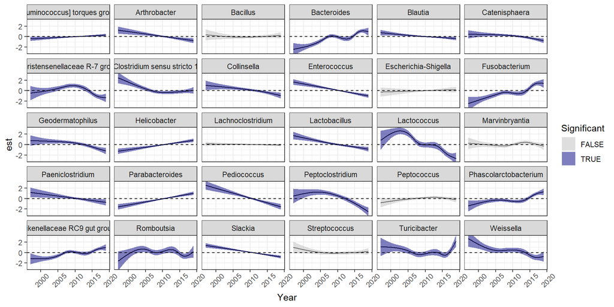

```r
year_estimates_df$Significant <-year_estimates_df$P_val<0.05

year_estimates_df$Year<-as.numeric(rescale(year_estimates_df$Date_scaled, to = c(1997,2019)))


ggplot(year_estimates_df, aes(x = Year, y = est))+geom_line()+geom_ribbon(aes(ymin = lower, ymax = upper, fill = Significant), alpha = 0.5)+
  facet_wrap(~Taxa)+ theme_bw()+
  scale_fill_manual(values = c("grey", "navyblue"))+
  theme(axis.text.x = element_text(angle = 45, vjust=0.7))+
  geom_hline(yintercept = 0, linetype = "dashed")+
  coord_cartesian(ylim = c(-3,3))
```

```r
year_estimates_red<- subset(year_estimates_df, Taxa == "Lactococcus"| Taxa == "Pediococcus"| Taxa == "Weissella"|Taxa == "Bacteroides" | Taxa == "Fusobacterium" | Taxa == "Rikenellaceae RC9 gut group" )



year_estimates_red$Taxa<-factor(year_estimates_red$Taxa, levels = c("Bacteroides",  "Rikenellaceae RC9 gut group","Fusobacterium", "Lactococcus", "Pediococcus", "Weissella"))
unique(year_estimates_red$Taxa)
```

```
## [1] Weissella                   Rikenellaceae RC9 gut group
## [3] Bacteroides                 Pediococcus
## [5] Fusobacterium               Lactococcus
## 6 Levels: Bacteroides Rikenellaceae RC9 gut group ... Weissella
```

```r
year_estimates_red$Class <- ifelse(year_estimates_red$Taxa == "Bacteroides" | year_estimates_red$Taxa == "Rikenellaceae RC9 gut group", "Bacteroidia", NA)
year_estimates_red$Class <- ifelse(year_estimates_red$Taxa == "Fusobacterium" , "Fusobacteria", year_estimates_red$Class)
year_estimates_red$Class <- ifelse(year_estimates_red$Taxa == "Lactococcus" | year_estimates_red$Taxa == "Pediococcus"| year_estimates_red$Taxa == "Weissella", "Bacilli",  year_estimates_red$Class)

levels(year_estimates_red$Taxa)<-c("a) Bacteroides", "b) Rikenellaceae RC9","c) Fusobacterium", "d) Lactococcus (LAB)", "e) Pediococcus (LAB)", "f) Weissella (LAB)")



ggplot(year_estimates_red,aes(x = Year, y = est))+
  geom_line(size = 0.8, aes(col = Class))+
  geom_line(size = 0.8, alpha = 0.4, col = "black")+
  facet_wrap(~Taxa, ncol = 3)+
  geom_ribbon(aes(ymin = lower, ymax = upper, fill = Class ), alpha = 0.7)+
  coord_cartesian(ylim = c(-3.5,3.5))+
  geom_hline(yintercept = 0, linetype = "dashed")+
  scale_fill_manual(values = c(pal[1], pal[8], pal[7]))+
  scale_color_manual(values = c(pal[1], pal[8], pal[7]))+
   theme_fira() +
 theme(plot.margin=unit(c(0.2,0.5,0,0.2),"cm"))+
  #labs(fill = "Class", col = "Genus")+
  ylab("Estimate")+
  xlab("")+
    theme(axis.text.x = element_text(angle = 45, vjust=0.7))+
 annotate("segment", x=-Inf, xend=Inf, y=-Inf, yend=-Inf, col = "black")+
  annotate("segment", x=-Inf, xend=-Inf, y=-Inf, yend=Inf, col = "darkgrey")+
  theme(panel.grid.major = element_blank())
```

```
## Error in theme_fira(): could not find function "theme_fira"
```

```r
# firatheme::firaSave("C:/Users/risel/Dropbox/Sommer postdoc/Meerkat project/PROJECTS/MeerkatSpikeInData/Manuscripts/TB population level paper/GCB/Resubmission/Figures/fig3.pdf", device = "pdf")
```

This chunk took 0.05 minutes

# 6 Fig. 4: JDSMs

```r
# Using scaled counts


meerkat_genus<-microbiome::aggregate_top_taxa(meerkat_filtered, "Genus", top = 50)
clr_scaled <-microbiome::transform(meerkat_genus, transform = "clr")


taxa_to_keep <- c("[Ruminococcus] torques group" , "Arthrobacter", "Bacillus","Bacteroides",
 "Blautia", "Catenisphaera" ,"Christensenellaceae R-7 group", "Clostridium sensu stricto 1",
"Collinsella" ,"Enterococcus" , "Escherichia-Shigella","Fusobacterium",
"Geodermatophilus","Lachnoclostridium", "Lactococcus" ,"Marvinbryantia" ,
"Paeniclostridium","Peptoclostridium" , "Peptococcus" ,"Phascolarctobacterium",
"Romboutsia", "Slackia" ,"Turicibacter" , "Weissella" ,
"Rikenellaceae RC9 gut group", "Helicobacter" , "Parabacteroides", "Lactobacillus",
 "Pediococcus", "Streptococcus" )

#meerkat_genus<-microbiome::aggregate_top_taxa(meerkat_filtered, "Genus", top = 50)

#meerkat_genus_scaled<-prune_taxa(taxa_to_keep, meerkat_genus)
meerkat_genus_scaled<-prune_taxa(taxa_to_keep,clr_scaled) # new
meerkat_genus_scaled<-subset_samples(meerkat_genus_scaled, !is.na(Mean_rainfall_12month_NOAA))


#############

taxa_names(meerkat_genus_scaled)
```

```
##  [1] "[Ruminococcus] torques group"  "Arthrobacter"
##  [3] "Bacillus"                      "Bacteroides"
##  [5] "Blautia"                       "Catenisphaera"
##  [7] "Christensenellaceae R-7 group" "Clostridium sensu stricto 1"
##  [9] "Collinsella"                   "Enterococcus"
## [11] "Escherichia-Shigella"          "Fusobacterium"
## [13] "Geodermatophilus"              "Helicobacter"
## [15] "Lachnoclostridium"             "Lactobacillus"
## [17] "Lactococcus"                   "Marvinbryantia"
## [19] "Paeniclostridium"              "Parabacteroides"
## [21] "Pediococcus"                   "Peptoclostridium"
## [23] "Peptococcus"                   "Phascolarctobacterium"
## [25] "Rikenellaceae RC9 gut group"   "Romboutsia"
## [27] "Slackia"                       "Streptococcus"
## [29] "Turicibacter"                  "Weissella"
```

```r
taxa_names(meerkat_genus_scaled)[10]<-paste(taxa_names(meerkat_genus_scaled)[10], "(LAB)")
taxa_names(meerkat_genus_scaled)[16]<-paste(taxa_names(meerkat_genus_scaled)[16], "(LAB)")
taxa_names(meerkat_genus_scaled)[17]<-paste(taxa_names(meerkat_genus_scaled)[17], "(LAB)")
taxa_names(meerkat_genus_scaled)[21]<-paste(taxa_names(meerkat_genus_scaled)[21], "(LAB)")
taxa_names(meerkat_genus_scaled)[28]<-paste(taxa_names(meerkat_genus_scaled)[28], "(LAB)")
taxa_names(meerkat_genus_scaled)[30]<-paste(taxa_names(meerkat_genus_scaled)[30], "(LAB)")
```

This chunk took 0.05 minutes

- Data preparation

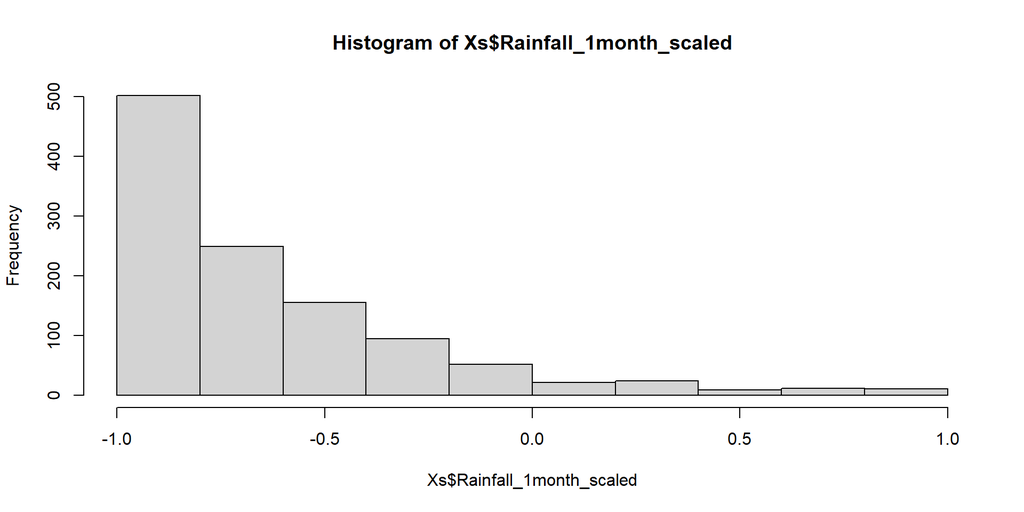

```r
ys <- data.frame(t(otu_table(meerkat_genus_scaled)))

names(ys) <-taxa_names(meerkat_genus_scaled)


#y<-data.frame(scale(y))
Xs<-data.frame(sample_data(meerkat_genus_scaled))



Xs$Rainfall_1month_scaled <-as.numeric(rescale(Xs$Mean_rainfall_1month_NOAA, to = c(-1,1)))
hist(Xs$Rainfall_1month_scaled)
```

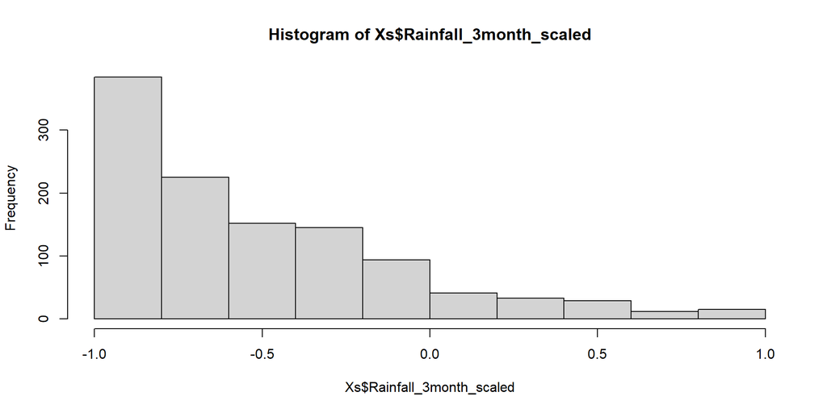

```r
Xs$Rainfall_3month_scaled <-as.numeric(rescale(Xs$Mean_rainfall_3month_NOAA, to = c(-1,1)))
hist(Xs$Rainfall_3month_scaled)
```

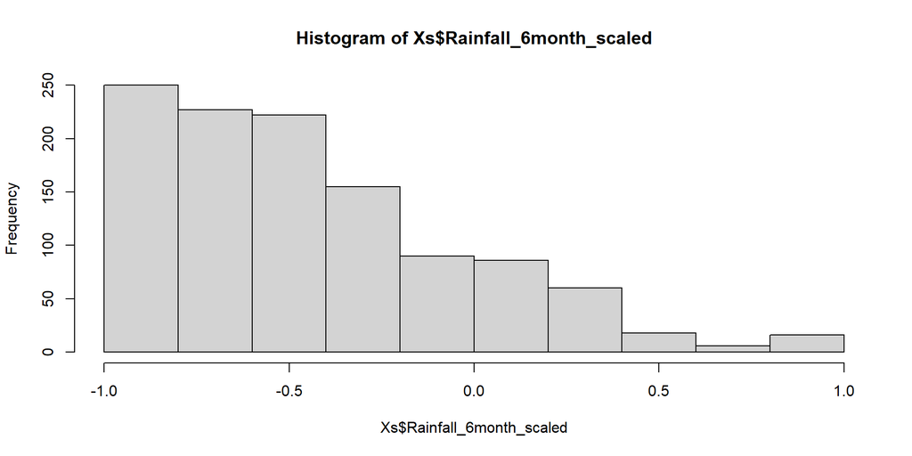

```r
Xs$Rainfall_6month_scaled <-as.numeric(rescale(Xs$Mean_rainfall_6month_NOAA, to = c(-1,1)))
hist(Xs$Rainfall_6month_scaled)
```

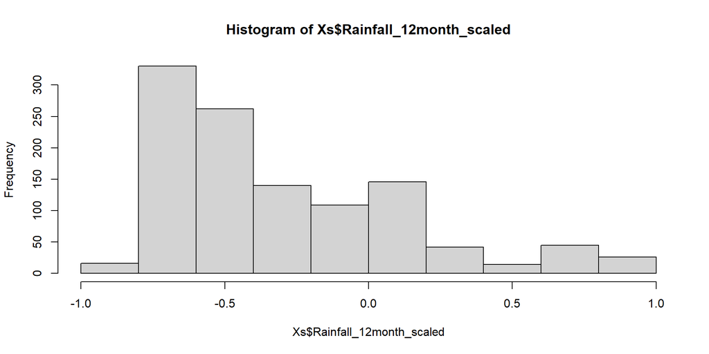

```r
Xs$Rainfall_12month_scaled <-as.numeric(rescale(Xs$Mean_rainfall_12month_NOAA, to = c(-1,1)))
hist(Xs$Rainfall_12month_scaled)
```

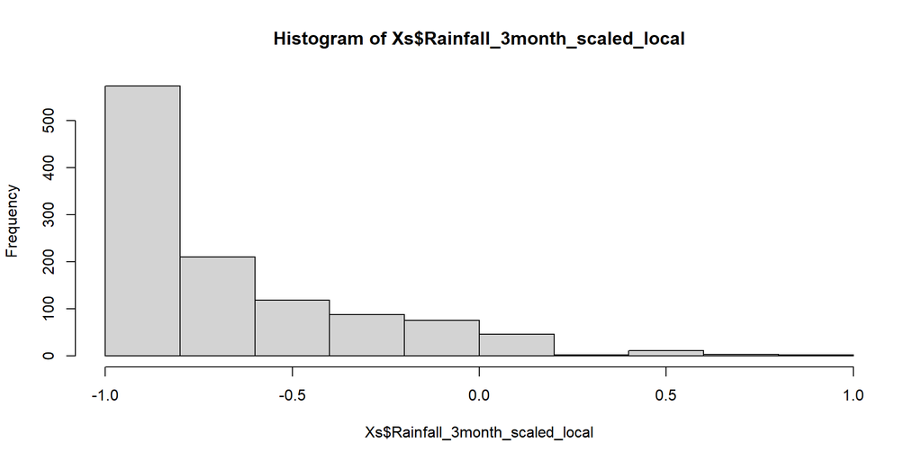

```r
## KRC/VZ rainfall data

Xs$Rainfall_3month_scaled_local <-as.numeric(rescale(Xs$Mean_rainfall_3month, to = c(-1,1)))
hist(Xs$Rainfall_3month_scaled_local)
```

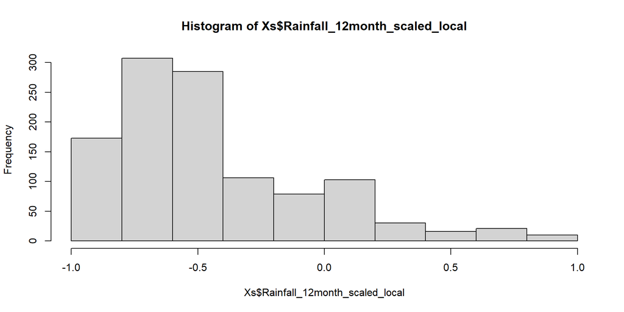

```r
Xs$Rainfall_12month_scaled_local <-as.numeric(rescale(Xs$Mean_rainfall_12month, to = c(-1,1)))
hist(Xs$Rainfall_12month_scaled_local)
```

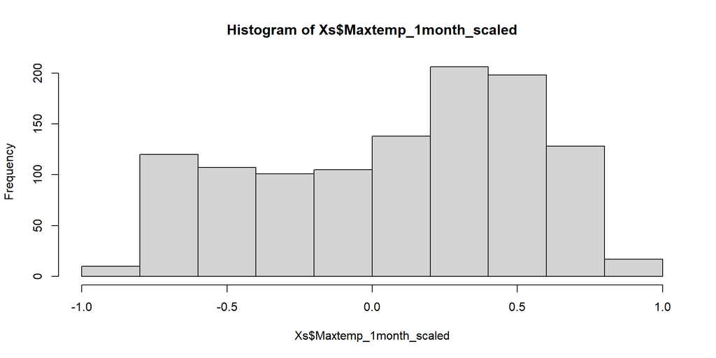

```r
## temperature


Xs$Maxtemp_1month_scaled <-as.numeric(rescale(Xs$Mean_maxtemp_1month, to = c(-1,1)))
hist(Xs$Maxtemp_1month_scaled)
```

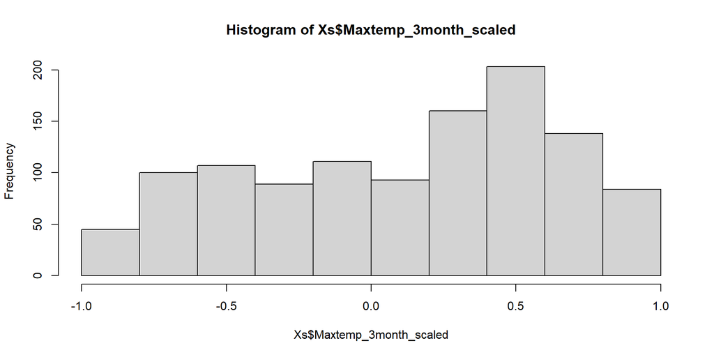

```r
Xs$Maxtemp_3month_scaled <-as.numeric(rescale(Xs$Mean_maxtemp_3month, to = c(-1,1)))
hist(Xs$Maxtemp_3month_scaled)
```

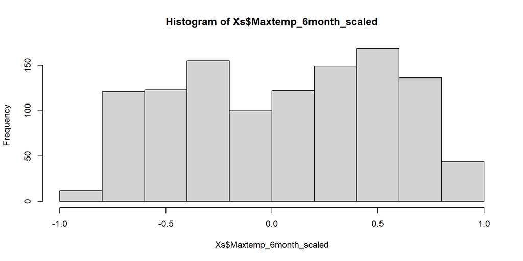

```r
Xs$Maxtemp_6month_scaled <-as.numeric(rescale(Xs$Mean_maxtemp_6month, to = c(-1,1)))
hist(Xs$Maxtemp_6month_scaled)
```

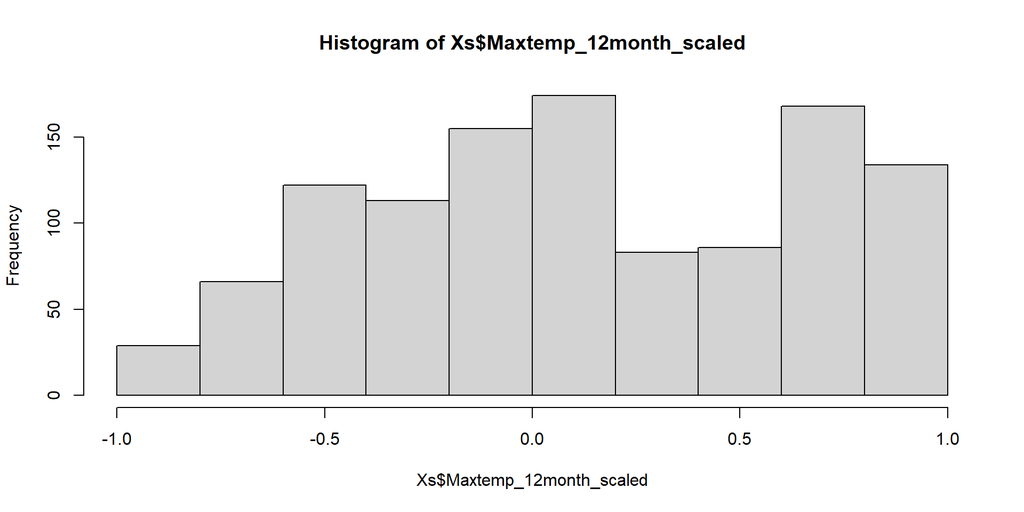

```r
Xs$Maxtemp_12month_scaled <-as.numeric(rescale(Xs$Mean_maxtemp_12month, to = c(-1,1)))
hist(Xs$Maxtemp_12month_scaled)
```

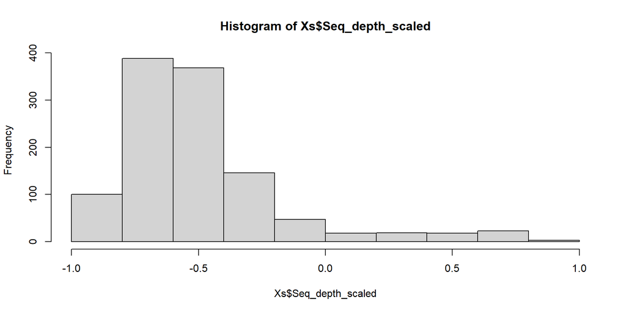

```r
### seq depth
### seq depth

#Xs$Abundance_scaled <- as.numeric(rescale(Xs$TotalAbundance, to = c(-1,1)))
Xs$Seq_depth_scaled <- as.numeric(rescale(Xs$Seq_depth_nospikein, to = c(-1,1)))
hist(Xs$Seq_depth_scaled)
```

```r
#Xs$TotalAbundance_scaled <- rescale(Xs$TotalAbundance, to = c(-1,1))

Xs$Year<-as.factor(Xs$Year)

min(Xs$SampleDate)
```

```
## [1] "1997-07-07"
```

```r
Xs$Date<- as.numeric(Xs$SampleDate - min(Xs$SampleDate))
Xs$Date_scaled<-as.numeric(rescale(Xs$Date, to = c(-1,1)))


Xs$Condition_scaled<-as.numeric(rescale(Xs$Condition_weight, to = c(-1,1)))
Xs$Age_scaled<-as.numeric(rescale(Xs$AgeAtSampling, to = c(-1,1)))

Xs$TB_stage<-factor(Xs$TB_stage, levels = c( "Unexposed","Exposed", "Diseased"))

names(Xs)
```

```
##  [1] "feature.id"                    "IndividID"
##  [3] "SampleDate"                    "SampleTime"
##  [5] "Storage"                       "Seq_run"
##  [7] "Imtechella"                    "Allobacillus"
##  [9] "Seq_depth"                     "scaling_factor"
## [11] "Seq_depth_nospikein"           "BirthDate"
## [13] "DeathDate"                     "AgeAtSampling"
## [15] "GroupAtSampling"               "Condition_weight"
## [17] "SocialStatus"                  "Temp_max"
## [19] "sum_rainfall_month"            "HoursAfterSunrise"
## [21] "TimeCat"                       "Year"
## [23] "month"                         "Season"
## [25] "TB_status"                     "TB_exposure"
## [27] "TB_resistance"                 "TB_survival"
## [29] "TB_symptom_date"               "TB_exposure_date"
```

[output cut: 17 more lines]

```r
Xs<-Xs[,c(1,2, 15, 5, 22, 24, 21, 31,33, 49:60,62:64)]
```

```
## Error in `[.data.frame`(Xs, , c(1, 2, 15, 5, 22, 24, 21, 31, 33, 49:60, : undefined columns selected
```

```r
names(Xs)
```

```
##  [1] "feature.id"                    "IndividID"
##  [3] "SampleDate"                    "SampleTime"
##  [5] "Storage"                       "Seq_run"
##  [7] "Imtechella"                    "Allobacillus"
##  [9] "Seq_depth"                     "scaling_factor"
## [11] "Seq_depth_nospikein"           "BirthDate"
## [13] "DeathDate"                     "AgeAtSampling"
## [15] "GroupAtSampling"               "Condition_weight"
## [17] "SocialStatus"                  "Temp_max"
## [19] "sum_rainfall_month"            "HoursAfterSunrise"
## [21] "TimeCat"                       "Year"
## [23] "month"                         "Season"
## [25] "TB_status"                     "TB_exposure"
## [27] "TB_resistance"                 "TB_survival"
## [29] "TB_symptom_date"               "TB_exposure_date"
```

[output cut: 17 more lines]

```r
mr<-mean(Xs$Rainfall_12month_scaled)
mt<-mean(Xs$Maxtemp_12month_scaled)

Xs$Climate_cat <-ifelse(Xs$Maxtemp_12month_scaled>mt & Xs$Rainfall_12month_scaled < mr, "HighTemp_LowRainfall", NA)
Xs$Climate_cat <-ifelse(Xs$Maxtemp_12month_scaled<mt & Xs$Rainfall_12month_scaled < mr, "LowTemp_LowRainfall", Xs$Climate_cat)
Xs$Climate_cat <-ifelse(Xs$Maxtemp_12month_scaled<mt & Xs$Rainfall_12month_scaled > mr, "LowTemp_HighRainfall", Xs$Climate_cat)
Xs$Climate_cat <-ifelse(Xs$Maxtemp_12month_scaled>mt & Xs$Rainfall_12month_scaled > mr, "HighTemp_HighRainfall", Xs$Climate_cat)
table(Xs$Climate_cat)
```

```
##
## HighTemp_HighRainfall  HighTemp_LowRainfall  LowTemp_HighRainfall
##                   175                   351                   281
##   LowTemp_LowRainfall
##                   323
```

```r
Xs$Climate_cat<-factor(Xs$Climate_cat, levels = c("LowTemp_HighRainfall", "HighTemp_LowRainfall", "HighTemp_HighRainfall", "LowTemp_LowRainfall"))

Xs$Season <-factor(Xs$Season, levels = c("WET", "DRY"))



head(ys)[1:5,1:5]
```

|  | [Ruminococcus] torques group | Arthrobacter | Bacillus | Bacteroides | Blautia |
| --- | --- | --- | --- | --- | --- |
| Feature3 | 4.683748 | -3.792408 | -0.5850204 | 0.7462249 | 6.170979 |
| Feature5 | 2.465549 | 3.086119 | -3.3162032 | 1.0323142 | 3.997452 |
| Feature7 | 3.899302 | -3.062844 | 4.1222557 | -3.0628443 | 5.242336 |
| Feature8 | 3.881137 | -3.783119 | -3.7831192 | 1.9143570 | 5.608095 |
| Feature10 | 3.055708 | -2.880239 | -2.8802393 | 1.9630049 | 2.954621 |

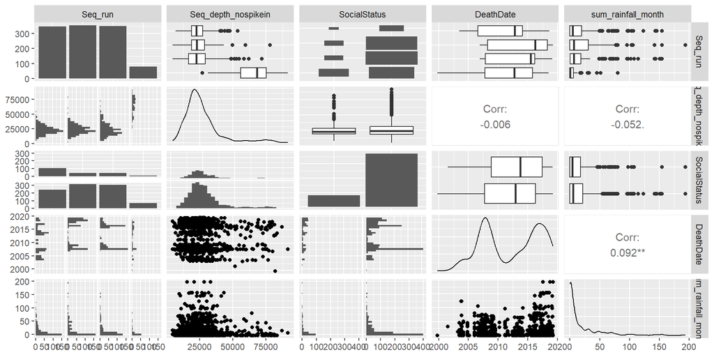

```r
ggpairs(Xs[,c(6,11,17,13,19)])
```

This chunk took 0.09 minutes

- Model fitting - reduced model with just date and methodological variables (plus time of day - biggest driver of composition)

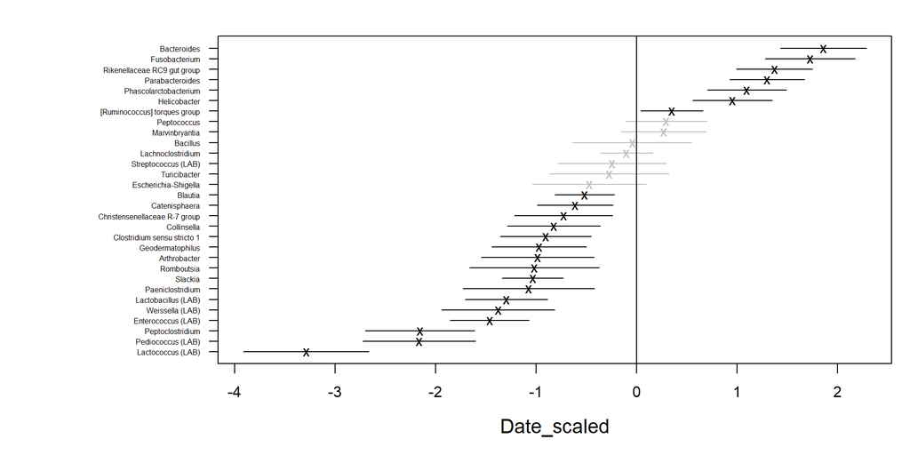

```r
fit_reduced_scaled <- gllvm(ys, Xs,
             num.lv = 2,
            formula = ~  Date_scaled+Storage+TimeCat+ Seq_depth_scaled,
             family = "gaussian",
            row.eff = ~(1|IndividID)+ (1|GroupAtSampling))

coefplot(fit_reduced_scaled, cex.ylab = 0.5 ,mar = c(5,12,2,1), which.Xcoef = c(1))
```

This chunk took 11.42 minutes

- Extract estimates

```r
df<-coef(fit_reduced_scaled)
est_df<-data.frame(df$Intercept)
est_df2<-data.frame(df$Xcoef)
est_df3<-merge(est_df, est_df2, by = 0)

# order genera

row.names(est_df3)<-est_df3$Row.names
est_df3<-est_df3[colnames(ys),]

#put est_df3 into long format

names(est_df3)[1]<- "Genus"
names(est_df3)[2]<- "Intercept"

estimates_df <- gather(est_df3, Treatment, Estimate, names(est_df3)[2]:names(est_df3)[ncol(est_df3)], factor_key=TRUE)

############# extract confindence intervals  ####
############# extract confindence intervals  ####
############# extract confindence intervals  ####
############# extract confindence intervals  ####


confint_df<-data.frame(confint(fit_reduced_scaled))


confint_df<-rbind(confint_df[rownames(confint_df) %like% "Xcoef", ],
confint_df[rownames(confint_df) %like% "Intercept", ])

head(confint_df)
```

|  | X2.5.. | X97.5.. |
| --- | --- | --- |
| Xcoef.Date_scaled:[Ruminococcus] torques group | 0.04040856 | 0.6631450 |
| Xcoef.Date_scaled:Arthrobacter | -1.54881511 | -0.4216695 |
| Xcoef.Date_scaled:Bacillus | -0.63541178 | 0.5490637 |
| Xcoef.Date_scaled:Bacteroides | 1.43085594 | 2.2923909 |
| Xcoef.Date_scaled:Blautia | -0.81490449 | -0.2219848 |
| Xcoef.Date_scaled:Catenisphaera | -0.99009370 | -0.2345646 |

```r
# add a column with correct variable level
variables<- colnames(est_df3)[3:ncol(est_df3)]
variables<-c(variables, "Intercept")
variables1<-rep(variables, nrow(est_df))
variables2<-variables1[order(match(variables1, variables))]

confint_df$Treatment<-variables2


# column with taxa names. Should be automatically in the correct order but double check

confint_df$Genus<-rep(colnames(ys), length(unique(confint_df$Treatment)))


merged<-merge(estimates_df, confint_df, by = c("Treatment", "Genus"))


final_estimates_reduced<- merged
names(final_estimates_reduced)[4]<-"CI_lower"
names(final_estimates_reduced)[5]<-"CI_upper"

#final_estimates<- merged[,c(1,2,3,7,8)]
head(final_estimates_reduced)
```

|  | Treatment | Genus | Estimate | CI_lower | CI_upper |
| --- | --- | --- | --- | --- | --- |
| 1 | Date_scaled | [Ruminococcus] torques group | 0.35177676 | 0.04040856 | 0.6631450 |
| 2 | Date_scaled | Arthrobacter | -0.98524229 | -1.54881511 | -0.4216695 |
| 3 | Date_scaled | Bacillus | -0.04317404 | -0.63541178 | 0.5490637 |
| 4 | Date_scaled | Bacteroides | 1.86162343 | 1.43085594 | 2.2923909 |
| 5 | Date_scaled | Blautia | -0.51844466 | -0.81490449 | -0.2219848 |
| 6 | Date_scaled | Catenisphaera | -0.61232917 | -0.99009370 | -0.2345646 |

```r
unique(final_estimates_reduced$Treatment)
```

```
## [1] Date_scaled      Intercept        Seq_depth_scaled StorageFROZEN
## [5] TimeCatMORNING
## 5 Levels: Intercept Date_scaled StorageFROZEN ... Seq_depth_scaled
```

```r
final_estimates_reduced2<-subset(final_estimates_reduced, Treatment == "Date_scaled")

## add significance

final_estimates_reduced2$Sig<- !data.table::between(0, final_estimates_reduced2$CI_lower, final_estimates_reduced2$CI_upper)


final_estimates_reduced2$Genus<-factor(final_estimates_reduced2$Genus)

genus_order<-as.character((final_estimates_reduced2 %>% arrange(Estimate))$Genus)
```

This chunk took 0.02 minutes

*full model

- see JDSM_model_selection.R for model selection

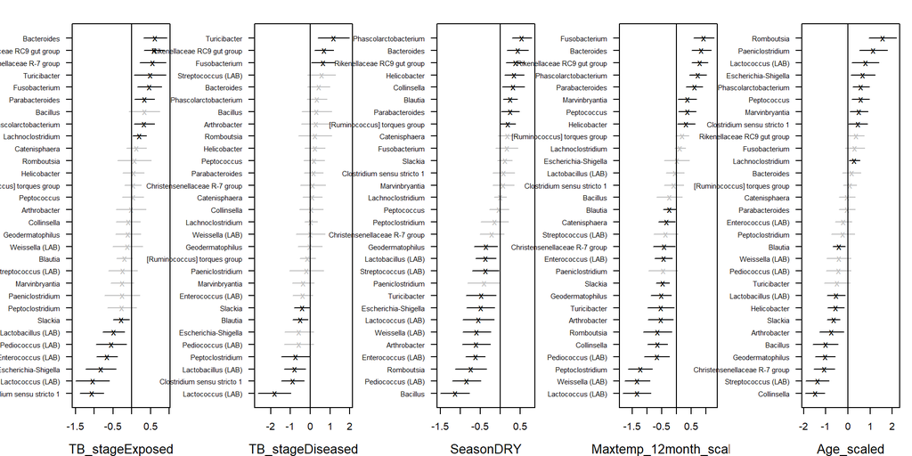

```r
########## final model

m_final <- gllvm(ys, Xs,
             num.lv = 2,
             formula = ~
             TB_stage +
             Season+
             Maxtemp_12month_scaled+
             Seq_depth_scaled+
             Storage +
             TimeCat+
             Age_scaled+
             Condition_scaled,
             family = "gaussian",
             row.eff = ~(1|IndividID)+ (1|GroupAtSampling))


coefplot(m_final, which.Xcoef = c(1:4, 8), cex.ylab = 0.7)
```

```r
### explanatory power ###


linpred_df<- data.frame(residuals(m_final)$linpred)
head(linpred_df)
```

|  | X1 | X2 | X3 | X4 | X5 | X6 | X7 | X8 | X9 | X10 | X11 | X12 | X13 | X14 | X15 | X16 | X17 | X18 | X19 | X20 | X21 | X22 | X23 | X24 | X25 | X26 | X27 | X28 | X29 | … |
| --- | --- | --- | --- | --- | --- | --- | --- | --- | --- | --- | --- | --- | --- | --- | --- | --- | --- | --- | --- | --- | --- | --- | --- | --- | --- | --- | --- | --- | --- | --- |
| Feature3 | 5.003130 | -2.8775895 | -1.3214425 | 1.3257942 | 5.776442 | 2.315160 | -0.1366677 | 4.343021 | 3.701025 | 4.390226 | -0.3614144 | 0.5889748 | 1.25576246 | -1.8060442 | 4.049410 | -3.090131 | 1.7686453 | 2.4585212 | 0.3640038 | -2.115108 | -1.7007443 | -1.032753 | 2.610568 | 0.3875243 | -1.853005 | 1.237584 | 2.820307 | -1.31654996 | -1.8982371 | … |
| Feature5 | 3.768953 | -1.2867422 | -0.7295338 | -0.1636243 | 4.364647 | 1.638542 | -0.4063934 | 6.544111 | 2.551667 | 4.993683 | -0.3008736 | -0.8021550 | 1.91171975 | -1.5061824 | 3.096727 | -2.438208 | 2.4373454 | 1.6939295 | 3.5961235 | -2.347928 | -0.5546994 | -1.413123 | 1.501725 | -0.7919980 | -2.276603 | 2.616067 | 2.471085 | 0.05277856 | -0.6804514 | … |
| Feature7 | 3.991334 | -0.8839021 | -1.0130069 | -1.2616294 | 5.004207 | 2.518959 | 0.3507905 | 6.525178 | 4.088582 | 5.088658 | -1.2297102 | -2.0580749 | 2.84461064 | -1.7471768 | 3.250694 | -2.107037 | 2.4966616 | 1.6257094 | 3.2424024 | -3.135859 | -0.4496800 | -1.343330 | 1.475290 | -1.6198880 | -3.161856 | 1.907168 | 3.467615 | 0.80224052 | -0.4575713 | … |
| Feature8 | 4.621216 | -3.4184923 | -4.4312342 | 1.0896976 | 4.753879 | 2.437342 | -0.9047019 | 6.178525 | 3.188453 | 3.375065 | -0.8858599 | 0.2257604 | 0.02762799 | -1.6118309 | 4.061509 | -3.441231 | 0.9112345 | 2.3857469 | 2.8612753 | -2.165799 | -2.8418386 | -1.334517 | 2.625245 | 0.5776295 | -1.210783 | 2.797632 | 2.657557 | -1.53517590 | -2.9480523 | … |
| Feature10 | 3.735650 | -2.3350430 | -2.1896043 | 1.1948440 | 4.221264 | 1.098129 | -1.0186324 | 6.664446 | 2.037085 | 3.997647 | -0.4909197 | 0.2191666 | 0.90715790 | -0.6723875 | 2.820335 | -3.116584 | 1.4159107 | 1.5838811 | 3.2016131 | -1.365868 | -1.8295498 | -1.910801 | 1.203539 | 0.4627874 | -1.183858 | 1.905438 | 1.937679 | -0.73816229 | -1.4843643 | … |
| Feature12 | 3.420177 | -0.9326999 | 0.1718295 | -0.4245905 | 4.232147 | 1.882565 | 1.1784241 | 4.833853 | 2.130725 | 5.057694 | -0.8702326 | -0.3338452 | 3.22481454 | -2.2793402 | 3.522168 | -2.097291 | 3.0169109 | 0.8856915 | 1.6305142 | -2.748418 | -0.7410328 | -1.804966 | 1.526654 | -0.5588597 | -2.587363 | 1.662595 | 2.046717 | -0.59319899 | 0.1450531 | … |

```r
names(linpred_df)<-names(ys)


r2_list<-list()
taxanames<-names(linpred_df)

for (i in 1:length(taxanames)){
r <- as.numeric(cor(linpred_df[,i], ys[i]))
r2<-r^2

r2_list[i]<- r2
}

r2_df<-data.frame(do.call(rbind, r2_list))
r2_df$Genus<-taxanames
names(r2_df)[1]<-"R2"
summary(r2_df$R2)
```

```
##    Min. 1st Qu.  Median    Mean 3rd Qu.    Max.
## 0.07585 0.23247 0.33920 0.38397 0.54570 0.76023
```

```r
r2_df %>% arrange(R2)
```

| R2 | Genus |
| --- | --- |
| 0.07584719 | Escherichia-Shigella |
| 0.12042273 | Peptoclostridium |
| 0.15460941 | Romboutsia |
| 0.18129774 | Paeniclostridium |
| 0.18376631 | Streptococcus (LAB) |
| 0.22071973 | Clostridium sensu stricto 1 |
| 0.22246704 | Weissella (LAB) |
| 0.22414263 | Peptococcus |
| 0.25743873 | Lactobacillus (LAB) |
| 0.26242633 | Pediococcus (LAB) |

[output cut: 20 more lines]

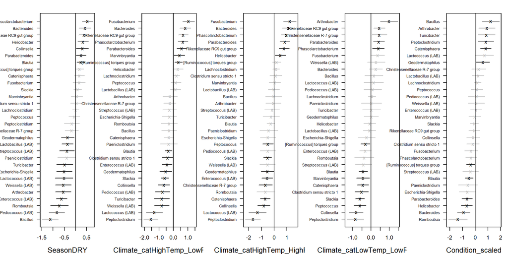

```r
# Min.   1st Qu.  Median    Mean 3rd Qu.    Max.
#0.07585 0.23246 0.33921 0.38398 0.54571 0.76018

#####


m_climate <- gllvm(ys, Xs,
             num.lv = 2,
             formula = ~
             TB_stage +
            Season+
             Climate_cat+
             Seq_depth_scaled+
             Storage +
             TimeCat+
             Age_scaled+
            Condition_scaled,
             family = "gaussian",
             row.eff = ~(1|IndividID)+ (1|GroupAtSampling))
coefplot(m_climate, which.Xcoef = c(3:6, 11), cex.ylab = 0.7)
```

```r
#### null model

m_null2 <- gllvm(ys, Xs,
             num.lv = 2,
             formula = ~
            # TB_stage +
            #Season+
             #Rainfall_3month_scaled +
             #Rainfall_12month_scaled+
            # Maxtemp_3month_scaled+
             #Maxtemp_12month_scaled+
             Seq_depth_scaled+
             Storage+
             TimeCat+
             Age_scaled,
            #Condition_scaled,
             family = "gaussian",
            row.eff = ~(1|IndividID)+ (1|GroupAtSampling))

cov_env<-getResidualCov(m_final, adjust = 0)#
cov_null<-getResidualCov(m_null2, adjust = 0)#

# variance explained (full model compared to null model)
1 - cov_env$trace / cov_null$trace
```

```
## [1] 0.079077
```

|  | df | AIC |
| --- | --- | --- |
| m_rainfall | 390 | 145992.6 |
| m_final | 390 | 145933.5 |

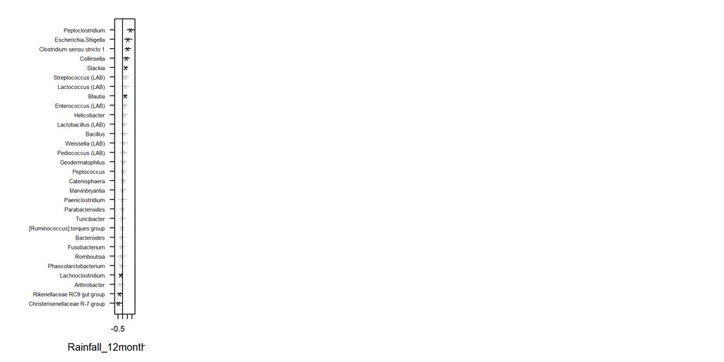

```r
################
################
################
################

# effect of rainfall

m_rainfall <- gllvm(ys, Xs,
             num.lv = 2,
             formula = ~
             TB_stage +
              Season+
             Rainfall_12month_scaled+
             Seq_depth_scaled+
             Storage +
             TimeCat+
             Age_scaled+
            Condition_scaled,
             family = "gaussian",
             row.eff = ~(1|IndividID)+ (1|GroupAtSampling))

coefplot(m_rainfall, which.Xcoef = c(4), cex.ylab = 0.7, mar = c(5,12,2,1))

AIC(m_rainfall, m_final) # AIC comparison
```

This chunk took 48.99 minutes

*Extract estimates

```r
genus_order<-as.character((final_estimates_reduced2 %>% arrange(Estimate))$Genus)


df<-coef(m_final)
est_df<-data.frame(df$Intercept)
est_df2<-data.frame(df$Xcoef) # choose columns of interest
est_df3<-merge(est_df, est_df2, by = 0)


# order genera

row.names(est_df3)<-est_df3$Row.names
est_df3<-est_df3[colnames(ys),]

#put est_df3 into long format

names(est_df3)[1]<- "Genus"
names(est_df3)[2]<- "Intercept"

estimates_df <- gather(est_df3, Treatment, Estimate, names(est_df3)[2]:names(est_df3)[ncol(est_df3)], factor_key=TRUE)

############# extract confindence intervals  ####
############# extract confindence intervals  ####
############# extract confindence intervals  ####
############# extract confindence intervals  ####


confint_df<-data.frame(confint(m_final))
confint_df<-rbind(confint_df[rownames(confint_df) %like% "Xcoef", ],
confint_df[rownames(confint_df) %like% "Intercept", ])


# add a column with correct variable level
variables<- colnames(est_df3)[3:ncol(est_df3)]
variables<-c(variables, "Intercept")
variables1<-rep(variables, nrow(est_df))
variables2<-variables1[order(match(variables1, variables))]


confint_df$Treatment<-variables2


# column with taxa names. Should be automatically in the correct order but double check

confint_df$Genus<-rep(colnames(ys), length(unique(confint_df$Treatment)))

# now have estimates, confidence intervals, aas seperate data frames, but they are in different formats. Need to massage them into one dataframe for plotting.

merged<-merge(estimates_df, confint_df, by = c("Treatment", "Genus"))


final_estimates<- merged
names(final_estimates)[4]<-"CI_lower"
names(final_estimates)[5]<-"CI_upper"


final_estimates2<-subset(final_estimates, Treatment == "TB_stageExposed" | Treatment == "TB_stageDiseased"| Treatment ==  "SeasonDRY"| Treatment ==  "Maxtemp_12month_scaled" |Treatment ==  "Condition_scaled")
unique(final_estimates2$Treatment)
```

```
## [1] Condition_scaled       Maxtemp_12month_scaled SeasonDRY
## [4] TB_stageDiseased       TB_stageExposed
## 10 Levels: Intercept TB_stageExposed TB_stageDiseased ... Condition_scaled
```

```r
## add significance

final_estimates2$Sig<- !data.table::between(0, final_estimates2$CI_lower, final_estimates2$CI_upper)


#########
#########
#########
#########

final_estimates3<-rbind(final_estimates2, final_estimates_reduced2)

levels(final_estimates3$Treatment)
```

```
##  [1] "Intercept"              "TB_stageExposed"        "TB_stageDiseased"
##  [4] "SeasonDRY"              "Maxtemp_12month_scaled" "Seq_depth_scaled"
##  [7] "StorageFROZEN"          "TimeCatMORNING"         "Age_scaled"
## [10] "Condition_scaled"       "Date_scaled"
```

```r
final_estimates3$Treatment<-factor(final_estimates3$Treatment)

final_estimates3$Treatment<-factor(final_estimates3$Treatment, levels = c( "Date_scaled","SeasonDRY", "Maxtemp_12month_scaled", "TB_stageExposed",  "TB_stageDiseased" , "Condition_scaled"))


### tax table ###
### tax table ###
### tax table ###
### tax table ###

meerkat_genus<-tax_glom(meerkat_final, taxrank = "Genus")
meerkat_genus<-core(meerkat_genus, detection = 0, prev = 0.1)

taxonomy<-data.frame(tax_table(meerkat_genus))
tax<-taxonomy[,c("Genus", "Class")]
tax<-distinct(tax, Genus, .keep_all = T)

unique(tax$Genus)%>%sort()
```

```
##   [1] "[Anaerorhabdus] furcosa group"
##   [2] "[Eubacterium] brachy group"
##   [3] "[Eubacterium] coprostanoligenes group"
##   [4] "[Eubacterium] nodatum group"
##   [5] "[Ruminococcus] gauvreauii group"
##   [6] "[Ruminococcus] torques group"
##   [7] "Acetivibrio"
##   [8] "Actinomadura"
##   [9] "Actinomyces"
##  [10] "Actinomycetospora"
##  [11] "Actinoplanes"
##  [12] "Aeromicrobium"
##  [13] "Agromyces"
##  [14] "Akkermansia"
##  [15] "Alistipes"
```

[output cut: 150 more lines]

```r
unique(final_estimates3$Genus) %>% sort()
```

```
##  [1] "[Ruminococcus] torques group"  "Arthrobacter"
##  [3] "Bacillus"                      "Bacteroides"
##  [5] "Blautia"                       "Catenisphaera"
##  [7] "Christensenellaceae R-7 group" "Clostridium sensu stricto 1"
##  [9] "Collinsella"                   "Enterococcus (LAB)"
## [11] "Escherichia-Shigella"          "Fusobacterium"
## [13] "Geodermatophilus"              "Helicobacter"
## [15] "Lachnoclostridium"             "Lactobacillus (LAB)"
## [17] "Lactococcus (LAB)"             "Marvinbryantia"
## [19] "Paeniclostridium"              "Parabacteroides"
## [21] "Pediococcus (LAB)"             "Peptoclostridium"
## [23] "Peptococcus"                   "Phascolarctobacterium"
## [25] "Rikenellaceae RC9 gut group"   "Romboutsia"
## [27] "Slackia"                       "Streptococcus (LAB)"
## [29] "Turicibacter"                  "Weissella (LAB)"
```

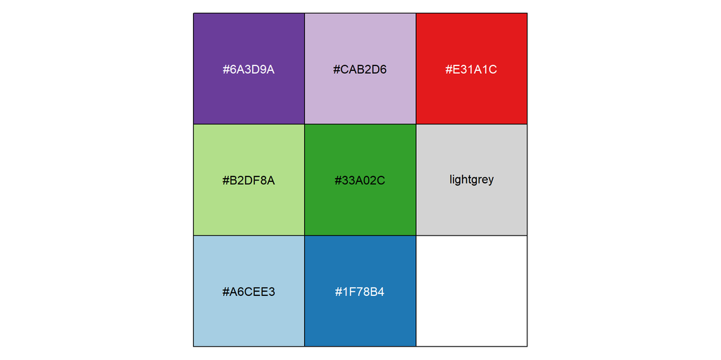

```r
tax$Genus <- ifelse(tax$Genus == "Lactococcus", "Lactococcus (LAB)", tax$Genus)
tax$Genus <- ifelse(tax$Genus == "Lactobacillus", "Lactobacillus (LAB)", tax$Genus)
tax$Genus <- ifelse(tax$Genus == "Enterococcus", "Enterococcus (LAB)", tax$Genus)
tax$Genus <- ifelse(tax$Genus == "Pediococcus", "Pediococcus (LAB)", tax$Genus)
tax$Genus <- ifelse(tax$Genus == "Streptococcus", "Streptococcus (LAB)", tax$Genus)
tax$Genus <- ifelse(tax$Genus == "Weissella", "Weissella (LAB)", tax$Genus)


final_estimates3$Class<-expss::vlookup(final_estimates3$Genus, tax, lookup_column = "Genus", result_column = "Class")


final_estimates3$Genus<-factor(final_estimates3$Genus, levels = genus_order)

# code genus colours

pal<-brewer.pal(10,"Paired")
pal<-c(pal, "lightgrey")
pal<-pal[c(2,1,11,4,3,6,9,10)]
pal<-rev(pal)
scales::show_col(pal)
```

```r
final_estimates3 <- final_estimates3 %>%
  mutate(Colour = case_when((Class == "Bacteroidia") ~ pal[8],
                             (Class == "Fusobacteriia") ~ pal[7],
                             (Class == "Clostridia") ~ pal[5],
                             (Class == "Bacilli") ~ pal[1] ))

final_estimates3$Colour<-ifelse(is.na(final_estimates3$Colour), "black", as.character(final_estimates3$Colour))


final_estimates3<-final_estimates3 %>% arrange( Treatment, Genus)

# variable labels

variable_names <- c(
                    `Date_scaled` = "a) Date",
                    `TB_stageExposed` = "d) TB status \n(Exposed)",
                    `TB_stageDiseased` = "e) TB status \n(Diseased)",
                    `SeasonDRY` = "b) Season \n(Dry)",
                    `Maxtemp_12month_scaled` = "c) Long-term \nmax. temp.",
                    `Condition_scaled` = "f) Body \ncondition"
                    )


final_estimates3<-final_estimates3 %>% arrange( Treatment, Genus)

## dummy data to keep x axis of most variables constant

Treatment <- rep(as.character(unique(final_estimates3$Treatment)),2)
Estimate<- c(2,2,2,2,2,2,-2,-2,-2,-2,-2,-2)
Genus<- c("Bacillus","Bacillus", "Bacillus","Bacillus","Bacillus", "Bacillus","Collinsella","Collinsella", "Collinsella","Collinsella","Collinsella", "Collinsella" )
Sig<-c(TRUE, TRUE, TRUE,TRUE, TRUE, TRUE,TRUE, TRUE, TRUE,TRUE, TRUE, TRUE )
dummydata<- data.frame(Treatment, Estimate, Genus, Sig)
dummydata$Treatment<-factor(dummydata$Treatment, levels = c( "Date_scaled","SeasonDRY", "Maxtemp_12month_scaled", "TB_stageExposed",  "TB_stageDiseased" , "Condition_scaled"))

fig4<-ggplot(final_estimates3, aes(y = Genus, x = Estimate, col = Sig, fill = Sig))+
  facet_wrap(~Treatment, scales = "free_x", nrow = 1, labeller = as_labeller(variable_names))  +
  geom_errorbarh(aes(xmin = CI_lower, xmax = CI_upper, col = Sig), height = 0, size = 1)+
   geom_point(size = 1.5, col = "black", pch = 21)+
 geom_vline(xintercept = 0, linetype = "longdash")+
  theme_bw(base_size = 12)+
  scale_color_manual(values = c("grey", "dodgerblue3"))+
  scale_fill_manual(values = c("grey", "dodgerblue3"))+
  theme(axis.title.y = element_blank())+
  theme(axis.text.y = element_text(face="bold", size = 8))+
  theme(axis.text.y = element_text(colour=final_estimates3$Colour))+
  theme(legend.position = "none")+
  theme(strip.text.x = element_text(size = 12, face="bold"))+
    geom_blank(data = dummydata)


#########################
#########################
#########################
#########################


pal1<-c(pal[1] , pal[8], pal[5],  pal[7], "black")

classes_to_keep<-c("Bacilli", "Clostridia", "Bacteroidia", "Fusobacteriia")
final_estimates3$Class2<-ifelse(final_estimates3$Class%in% classes_to_keep, final_estimates3$Class, "Other")

unique(final_estimates3$Class)
```

```
##  [1] "Bacilli"             "Clostridia"          "Coriobacteriia"
##  [4] "Actinobacteria"      "Erysipelotrichia"    "Gammaproteobacteria"
##  [7] "Campylobacteria"     "Negativicutes"       "Bacteroidia"
## [10] "Fusobacteriia"
```

```r
p1<-ggplot(final_estimates3, aes(y = Genus, x = Estimate, fill = Class2))+
  geom_col()+
  facet_wrap(~Treatment, nrow = 1, scales = "free_x", labeller = as_labeller(variable_names))  +
  scale_fill_manual(values = pal1)+
  labs(fill = "Class")

legend<-get_legend(p1)

top_panel<-ggarrange( fig4, legend, widths = c(10, 1))+
  theme(plot.margin=unit(c(0.2,2.5,0.2,0.5),"cm"))
```

This chunk took 0.22 minutes

### 6.0.1 Residual correlation plot

```r
cr1<-data.frame(getResidualCor(m_final))#

names(cr1)<-names(ys)
names(cr1)<-abbreviate(names(cr1), minlength = 15)
rownames(cr1)<-abbreviate(rownames(cr1), minlength = 15 )

cr2<-cor_pmat(cr1)

corplot<-ggcorrplot(cr1,
   hc.order = TRUE,
   outline.col = "white",
   type = "full",
   ggtheme = ggplot2::theme_minimal,
   tl.cex = 7.5,
   p.mat = cr2,
   sig.level = 0.05,
   #show.diag = F,
   insig = "blank",
  # colors = c("#6D9EC1", "white", "#E46726"))
   colors = c("blue", "white", "red"))+
     theme(axis.text.x = element_text(angle = 90, vjust=0.5))+
  theme(plot.margin=unit(c(0.2,0.2,0.2,2),"cm"))
```

This chunk took 0.01 minutes

### 6.0.2 Interaction between rainfall and climate

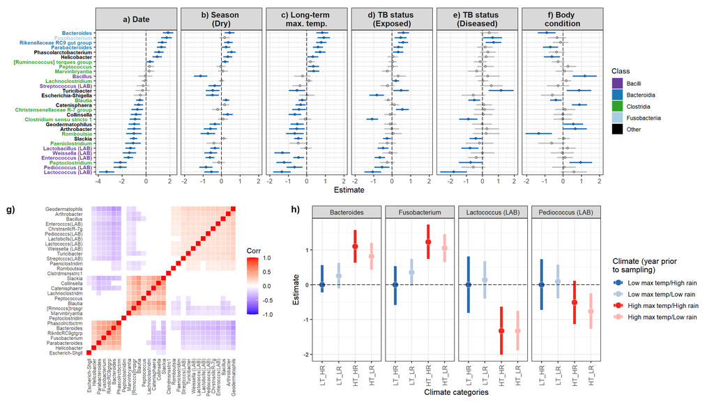

```r
df<-coef(m_climate)
est_df<-data.frame(df$Intercept)
est_df2<-data.frame(df$Xcoef)
est_df3<-merge(est_df, est_df2, by = 0)


# order genera

row.names(est_df3)<-est_df3$Row.names
est_df3<-est_df3[colnames(ys),]

#put est_df3 into long format

names(est_df3)[1]<- "Genus"
names(est_df3)[2]<- "Intercept"

estimates_df <- gather(est_df3, Treatment, Estimate, names(est_df3)[2]:names(est_df3)[ncol(est_df3)], factor_key=TRUE)

############# extract confindence intervals  ####
############# extract confindence intervals  ####
############# extract confindence intervals  ####
############# extract confindence intervals  ####


confint_df<-data.frame(confint(m_climate))

confint_df<-rbind(confint_df[rownames(confint_df) %like% "Xcoef", ],
confint_df[rownames(confint_df) %like% "Intercept", ])


# add a column with correct variable level
variables<- colnames(est_df3)[3:ncol(est_df3)]
variables<-c(variables, "Intercept")
variables1<-rep(variables, nrow(est_df))
variables2<-variables1[order(match(variables1, variables))]


confint_df$Treatment<-variables2


# column with taxa names. Should be automatically in the correct order but double check

confint_df$Genus<-rep(colnames(ys), length(unique(confint_df$Treatment)))



# now have estimates, confidence intervals, aas seperate data frames, but they are in different formats. Need to massage them into one dataframe for plotting.

merged<-merge(estimates_df, confint_df, by = c("Treatment", "Genus"))


final_estimates<- merged
names(final_estimates)[4]<-"CI_lower"
names(final_estimates)[5]<-"CI_upper"


terms<- c("Climate_catHighTemp_HighRainfall", "Climate_catHighTemp_LowRainfall",
  "Climate_catLowTemp_LowRainfall", "Intercept" )

final_estimates$Keep<-final_estimates$Treatment %in% terms


final_estimates2<-subset(final_estimates, Keep == T)

intercept<-subset(final_estimates2, Treatment == "Intercept")
intercept$CI_lower <- abs(abs(intercept$CI_lower) - abs(intercept$Estimate))*-1
intercept$CI_upper <- abs(abs(intercept$CI_upper) - abs(intercept$Estimate))
intercept$Estimate<-0

final_estimates2<-rbind(subset(final_estimates2, Treatment != "Intercept"), intercept)

final_estimates2$Treatment<-factor(final_estimates2$Treatment)

## add significance

final_estimates2$Sig<- !data.table::between(0, final_estimates2$CI_lower, final_estimates2$CI_upper)


#########
#########
#########
#########

levels(final_estimates2$Treatment)<- c("LT_HR", "HT_LR", "HT_HR", "LT_LR")
final_estimates2$Treatment<-factor(final_estimates2$Treatment, levels = c("LT_HR","LT_LR",  "HT_HR", "HT_LR"))


interaction_plot<-ggplot(subset(final_estimates2,
                                Genus == "Bacteroides" |Genus == "Fusobacterium" |
                                  Genus == "Lactococcus (LAB)"| Genus == "Pediococcus (LAB)" ),
                         aes(y = Estimate,x = Treatment, col = Treatment, fill = Treatment))+
  facet_wrap(~Genus,  nrow = 1)  +
  geom_errorbar(aes(ymin = CI_lower, ymax = CI_upper, col = Treatment), width = 0, size = 2)+
   geom_point(size = 4, col = "white", pch = 21)+
 geom_hline(yintercept = 0, linetype = "longdash")+
  theme_bw(base_size = 12)+
    theme(axis.text.x = element_text(angle = 90, vjust=0.5))+
  scale_colour_tableau('Classic Blue-Red 12', labels = c("Low max temp/High rain", "Low max temp/Low rain","High max temp/High rain", "High max temp/Low rain"))+
  scale_fill_tableau('Classic Blue-Red 12', labels = c("Low max temp/High rain", "Low max temp/Low rain","High max temp/High rain", "High max temp/Low rain"))+

  theme(axis.text.y = element_text(face="bold", size = 9))+
  labs(col = "Climate (year prior \nto sampling)", fill = "Climate (year prior \nto sampling)")+
  theme(plot.margin=unit(c(0.2,0.5,0.2,0.3),"cm"))+
  xlab("Climate categories")+
  ylab("Estimate")


lower_panel<- ggarrange( corplot,interaction_plot,  ncol = 2, widths = c(1,1.5),
                         labels = c("g)", "h)"), align = "h")+
   theme(plot.margin=unit(c(0,0,0.2,0.1),"cm"))


## figure 4
ggarrange(top_panel, lower_panel, ncol = 1, heights = c(1,1))
```

This chunk took 0.05 minutes

# 7 Fig 5: Network analysis

*Need to do CLR analysis from here as this accounts for bacterial load

```r
#### extract site x species array



meerkat_genus<-microbiome::aggregate_top_taxa(meerkat_filtered, "Genus", top = 50)
clr_scaled <-microbiome::transform(meerkat_genus, transform = "clr")


taxa_to_keep <- c("[Ruminococcus] torques group" , "Arthrobacter", "Bacillus","Bacteroides",
 "Blautia", "Catenisphaera" ,"Christensenellaceae R-7 group", "Clostridium sensu stricto 1",
"Collinsella" ,"Enterococcus" , "Escherichia-Shigella","Fusobacterium",
"Geodermatophilus","Lachnoclostridium", "Lactococcus" ,"Marvinbryantia" ,
"Paeniclostridium","Peptoclostridium" , "Peptococcus" ,"Phascolarctobacterium",
"Romboutsia", "Slackia" ,"Turicibacter" , "Weissella" ,
"Rikenellaceae RC9 gut group", "Helicobacter" , "Parabacteroides", "Lactobacillus",
 "Pediococcus", "Streptococcus" )

meerkat_genus_scaled<-prune_taxa(taxa_to_keep,clr_scaled) # new
meerkat_genus_scaled<-subset_samples(meerkat_genus_scaled, !is.na(Mean_rainfall_12month_NOAA))



phylo_array<-data.frame(t(meerkat_genus_scaled@otu_table@.Data))


#phylo_array[1:5,1:5]
names(phylo_array)<-taxa_names(meerkat_genus_scaled)

phylo_array[1:5,1:5]
```

|  | [Ruminococcus] torques group | Arthrobacter | Bacillus | Bacteroides | Blautia |
| --- | --- | --- | --- | --- | --- |
| Feature3 | 4.683748 | -3.792408 | -0.5850204 | 0.7462249 | 6.170979 |
| Feature5 | 2.465549 | 3.086119 | -3.3162032 | 1.0323142 | 3.997452 |
| Feature7 | 3.899302 | -3.062844 | 4.1222557 | -3.0628443 | 5.242336 |
| Feature8 | 3.881137 | -3.783119 | -3.7831192 | 1.9143570 | 5.608095 |
| Feature10 | 3.055708 | -2.880239 | -2.8802393 | 1.9630049 | 2.954621 |

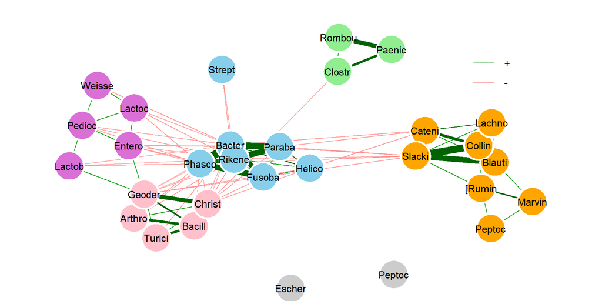

```r
##########################

#### genreate association matrix from the 'real' data
# this uses the package NetCoMi


net_real <- netConstruct(phylo_array, verbose = 0,
                         measure = "pearson",
                         normMethod = "none",
                         zeroMethod = "none",
                         sparsMethod = "threshold",
                         thresh = 0.3)


props_single <- netAnalyze(net_real,
                           centrLCC = TRUE,
                           clustMethod = "cluster_fast_greedy",
                           hubPar = "eigenvector",
                           weightDeg = F,
                           normDeg = F)



plot(props_single,
     nodeColor = "cluster",
     layout = "spring",
     repulsion = 1,
     # nodeSize = "eigenvector",
     title1 = F,
     #showTitle = TRUE,
     cexTitle = 2.3,
     shortenLabels = "simple",
     labelScale = F,
     nodeSize = "fix",
     colorVec = c("skyblue", "orchid",  "pink","orange", "lightgreen"),
     nodeTransp = 0,
     borderCol = "white",
     borderWidth = 3,
     highlightHubs = F ,
     edgeTranspLow = 0)

legend(0.7, 1.1, cex = 1, title = "Direction",
       legend = c("+","-"), lty = 1, lwd = 1, col = c("#009900","red"),
       bty = "n", horiz = F)
```

```r
cluster_memb<-data.frame(props_single$clustering$clust1)

names(cluster_memb)<-"Cluster"
table(cluster_memb$Cluster)
```

```
##
## 0 1 2 3 4 5
## 2 7 5 5 8 3
```

```r
# make singletons their own cluster (not zero)

cluster_memb$Genus<-row.names(cluster_memb)


cluster_memb<-cluster_memb %>% mutate(Cluster2 = case_when(Cluster == 2 ~ "Lactococcus cluster",
                                 Cluster == 1 ~ "Bacteroides cluster",
                                Cluster == 4 ~ "Blautia cluster",
                                 Cluster == 5 ~ "Clostridium cluster",
                                 Cluster == 3 ~ "Bacillus cluster",
                                 Genus == "Escherichia-Shigella" ~ "Escherichia-Shigella",
                                 Genus == "Peptoclostridium" ~ "Peptoclostridium"))
```

This chunk took 0.14 minutes

### 7.0.1 Survival analysis

```r
######### 2) Network approach ############
######### 2) Network approach ############
######### 2) Network approach ############
######### 2) Network approach ############

meerkat_genus<-microbiome::aggregate_top_taxa(meerkat_filtered, "Genus", top = 50)
taxtable<-data.frame(tax_table(meerkat_genus))
taxtable[1:5,1:2]
```

|  | Genus | unique |
| --- | --- | --- |
| [Eubacterium] coprostanoligenes group | [Eubacterium] coprostanoligenes group | [Eubacterium] coprostanoligenes group |
| [Ruminococcus] gauvreauii group | [Ruminococcus] gauvreauii group | [Ruminococcus] gauvreauii group |
| [Ruminococcus] torques group | [Ruminococcus] torques group | [Ruminococcus] torques group |
| Alloprevotella | Alloprevotella | Alloprevotella |
| Anaerobiospirillum | Anaerobiospirillum | Anaerobiospirillum |

```r
taxtable_new<-merge(taxtable, cluster_memb, by = "Genus", all.x = T)
taxtable_new<-taxtable_new[,c(1,4)]
taxtable_new$Cluster2<-ifelse(is.na(taxtable_new$Cluster2) ,"None",taxtable_new$Cluster2 )

rownames(taxtable_new)<-taxtable_new$Genus

meerkat_genus@tax_table@.Data[,1]<-taxtable_new$Cluster2


## merge by cluster

cluster_ps<-tax_glom(meerkat_genus, taxrank = "Genus")
tax_table(cluster_ps)
```

```
## Taxonomy Table:     [ 8 taxa by 2 taxonomic ranks ]:
##                               Genus                unique
##                               <chr>                <chr>
## 1 Unknown                     None                 <NA>
## 2 Blautia                     Blautia cluster      <NA>
## 3 Bacillus                    Bacillus cluster     <NA>
## 4 Bacteroides                 Bacteroides cluster  <NA>
## 5 Clostridium sensu stricto 1 Clostridium cluster  <NA>
## 6 Enterococcus                Lactococcus cluster  <NA>
## 7 Escherichia-Shigella        Escherichia-Shigella <NA>
## 8 Peptoclostridium            Peptoclostridium     <NA>
```

```r
cluster_clr <-microbiome::transform(cluster_ps, transform = "clr")

keep<-taxa_names(cluster_clr)[-1]

cluster_clr<-prune_taxa(keep, cluster_clr)
taxa_names(cluster_clr)
```

```
## [1] "Blautia"                     "Bacillus"
## [3] "Bacteroides"                 "Clostridium sensu stricto 1"
## [5] "Enterococcus"                "Escherichia-Shigella"
## [7] "Peptoclostridium"
```

```r
taxa_names(cluster_clr)<- c("Blautia cluster", "Bacillus cluster", "Bacteroides cluster",
                            "Clostridium cluster", "Lactococcus cluster", "Escherichia","Peptoclostridium" )


cluster_clr<-subset_samples(cluster_clr, !is.na(Mean_rainfall_12month_NOAA))

otutable<-data.frame(t(otu_table(cluster_clr)))

otutable<-data.frame(rescale(otutable, to = c(-1,1)))

### survival data ####
### survival data ####


survival_df<-data.frame(sample_data(cluster_clr))

# calculate if ID is alive 6 months later, TRUE = dead

survival_df$Time_180<-survival_df$SampleDate+180
survival_df$Survival_180<- ifelse(survival_df$Time_180 < survival_df$DeathDate, FALSE,TRUE)


table(survival_df$Survival_180)
```

```
##
## FALSE  TRUE
##   809   321
```

```r
survival_df$FollowUp_180<-180

survival_df_network<-merge(survival_df, otutable, by = 0)

#############
#############
#############
#############


survival_df_network$IndividID<-as.character(survival_df_network$IndividID)

survival_df_network$Condition_scaled<-as.numeric(rescale(survival_df_network$Condition_weight, to = c(-1,1)))
survival_df_network$Age_scaled<-as.numeric(rescale(survival_df_network$AgeAtSampling, to = c(-1,1)))
survival_df_network$Rainfall_12month_scaled <-as.numeric(rescale(survival_df_network$Mean_rainfall_12month_NOAA, to = c(-1,1)))
survival_df_network$Maxtemp_12month_scaled <-as.numeric(rescale(survival_df_network$Mean_maxtemp_12month, to = c(-1,1)))


survival_df_network$Season <-case_when(survival_df_network$Season == "WET" ~ "Wet",
                                       survival_df_network$Season == "DRY" ~ "Dry")

survival_df_network<-subset(survival_df_network, !is.na(Survival_180))

###### model #########
###### model #########
###### model #########
###### model #########


fit_network <- coxme::coxme(Surv(FollowUp_180, Survival_180) ~

                              Season +
                              Rainfall_12month_scaled+
                              Maxtemp_12month_scaled+
                              TB_stage +
                              SocialStatus +
                              Condition_scaled +
                              Age_scaled+
                              Lactococcus.cluster+
                              Bacteroides.cluster+
                             Blautia.cluster+
                              Bacillus.cluster+
                              Clostridium.cluster+
                             Peptoclostridium+
                              Escherichia+



                              (1 | IndividID),
                            data = survival_df_network)

summary(fit_network)
```

```
## Cox mixed-effects model fit by maximum likelihood
##   Data: survival_df_network
##   events, n = 321, 1130
##   Iterations= 7 55
##                     NULL Integrated    Fitted
## Log-likelihood -2206.135  -2047.758 -1917.464
##
##                    Chisq     df p    AIC     BIC
## Integrated loglik 316.75  16.00 0 284.75  224.41
##  Penalized loglik 577.34 117.41 0 342.53 -100.26
##
## Model:  Surv(FollowUp_180, Survival_180) ~ Season + Rainfall_12month_scaled +      Maxtemp_12month_scaled + TB_stage + SocialStatus + Condition_scaled +      Age_scaled + Lactococcus.cluster + Bacteroides.cluster +      Blautia.cluster + Bacillus.cluster + Clostridium.cluster +      Peptoclostrid…
## Fixed coefficients
##                                coef  exp(coef)  se(coef)     z       p
## SeasonWet               -0.47319949  0.6230058 0.1294986 -3.65 2.6e-04
## Rainfall_12month_scaled -0.76837109  0.4637679 0.1961352 -3.92 8.9e-05
## Maxtemp_12month_scaled  -0.29177173  0.7469390 0.1686160 -1.73 8.4e-02
## TB_stageExposed          1.35814096  3.8889568 0.2029298  6.69 2.2e-11
## TB_stageDiseased         2.57836527 13.1755821 0.2568758 10.04 0.0e+00
## SocialStatusSubordinate  0.56876726  1.7660886 0.2077073  2.74 6.2e-03
## Condition_scaled        -0.93013167  0.3945018 0.2492067 -3.73 1.9e-04
## Age_scaled               2.39800458 11.0012024 0.2255574 10.63 0.0e+00
## Lactococcus.cluster     -0.09865067  0.9060592 0.4845028 -0.20 8.4e-01
## Bacteroides.cluster      0.32768820  1.3877562 0.4841965  0.68 5.0e-01
## Blautia.cluster          0.46658870  1.5945454 0.6264349  0.74 4.6e-01
## Bacillus.cluster         0.78829341  2.1996393 0.7340475  1.07 2.8e-01
## Clostridium.cluster      0.24496060  1.2775710 0.4450542  0.55 5.8e-01
## Peptoclostridium         0.37853357  1.4601418 0.4590030  0.82 4.1e-01
## Escherichia              0.48797791  1.6290189 0.4101664  1.19 2.3e-01
##
## Random effects
##  Group     Variable  Std Dev   Variance
##  IndividID Intercept 0.9059378 0.8207232
```

```r
AIC(fit_network)
```

```
## [1] 4069.74
```

```r
### Dredge models

options(na.action = "na.fail")

dredge_genus_df<- MuMIn::dredge(fit_network)


write.csv(dredge_genus_df, "dredge_results_clusters.csv")

summary<-summary(model.avg(dredge_genus_df, subset = delta < 4))
summary
```

```
##
## Call:
## model.avg(object = dredge_genus_df, subset = delta < 4)
##
## Component model call:
## coxme::coxme(formula = Surv(FollowUp_180, Survival_180) ~ <28 unique
##      rhs>, data = survival_df_network)
##
## Component models:
##                           df   logLik    AICc delta weight
## 1/6/8/9/11/12/13/14      111 -1971.17 4190.68  0.00   0.14
## 1/5/6/8/9/11/12/13/14    112 -1971.01 4192.18  1.49   0.06
## 1/6/7/8/9/11/12/13/14    112 -1971.29 4192.24  1.56   0.06
## 1/6/9/11/12/13/14        111 -1972.34 4192.41  1.73   0.06
## 1/3/6/8/9/11/12/13/14    111 -1971.81 4192.46  1.78   0.06
## 1/2/6/8/9/11/12/13/14    113 -1969.72 4192.65  1.97   0.05
## 1/4/6/8/9/11/12/13/14    112 -1971.20 4192.84  2.15   0.05
## 1/6/8/9/10/11/12/13/14   113 -1970.44 4192.93  2.24   0.04
## 1/6/7/9/11/12/13/14      111 -1972.41 4193.20  2.52   0.04
## 1/6/8/11/12/13/14        115 -1968.16 4193.23  2.55   0.04
## 1/2/6/7/8/9/11/12/13/14  114 -1969.16 4193.52  2.84   0.03
## 1/5/6/7/8/9/11/12/13/14  113 -1971.15 4193.74  3.05   0.03
## 1/3/5/6/8/9/11/12/13/14  112 -1971.61 4193.97  3.29   0.03
## 1/3/6/7/8/9/11/12/13/14  112 -1971.90 4194.03  3.34   0.03
## 1/4/5/6/8/9/11/12/13/14  113 -1971.03 4194.20  3.52   0.02
## 1/3/6/8/11/12/13/14      114 -1969.73 4194.23  3.55   0.02
## 1/5/6/9/11/12/13/14      112 -1972.32 4194.25  3.56   0.02
## 1/6/11/12/13/14          114 -1969.82 4194.27  3.58   0.02
## 1/6/7/8/9/10/11/12/13/14 113 -1971.29 4194.38  3.70   0.02
## 1/6/9/10/11/12/13/14     111 -1972.87 4194.38  3.70   0.02
## 1/2/5/6/8/9/11/12/13/14  114 -1970.09 4194.44  3.76   0.02
## 1/5/6/8/9/10/11/12/13/14 114 -1969.81 4194.46  3.77   0.02
## 1/4/6/7/8/9/11/12/13/14  113 -1971.29 4194.47  3.79   0.02
## 1/5/6/8/11/12/13/14      115 -1968.30 4194.53  3.84   0.02
## 1/3/4/6/8/9/11/12/13/14  112 -1971.81 4194.63  3.95   0.02
## 1/3/6/9/11/12/13/14      112 -1972.03 4194.64  3.96   0.02
## 1/4/6/9/11/12/13/14      112 -1972.33 4194.66  3.97   0.02
## 1/2/6/8/11/12/13/14      116 -1966.70 4194.67  3.99   0.02
##
## Term codes:
```

[output cut: 34 more lines]

```
## Lactococcus.cluster     -0.45664    0.22673   2.014 0.044008 *
## Maxtemp_12month_scaled  -0.29559    0.16303   1.813 0.069816 .
## Rainfall_12month_scaled -0.75983    0.19705   3.856 0.000115 ***
## SeasonWet               -0.46174    0.12856   3.592 0.000329 ***
## SocialStatusSubordinate  0.54894    0.20623   2.662 0.007772 **
## TB_stageExposed          1.35694    0.20239   6.705  < 2e-16 ***
## TB_stageDiseased         2.57621    0.25693  10.027  < 2e-16 ***
## Clostridium.cluster     -0.16281    0.18710   0.870 0.384206
## Escherichia              0.13123    0.14257   0.920 0.357362
## Bacteroides.cluster     -0.11323    0.22052   0.513 0.607626
## Bacillus.cluster         0.19818    0.22145   0.895 0.370835
## Blautia.cluster         -0.06027    0.32390   0.186 0.852382
## Peptoclostridium        -0.02464    0.17279   0.143 0.886596
## ---
## Signif. codes:  0 '***' 0.001 '**' 0.01 '*' 0.05 '.' 0.1 ' ' 1
```

```r
#saveRDS(summary, "model_averaging_survival.RDS")
#readRDS("model_averaging_survival.RDS")


### final model


m_survival <- coxme::coxme(Surv(FollowUp_180, Survival_180) ~

                              Season +
                              Rainfall_12month_scaled+
                              Maxtemp_12month_scaled+
                              TB_stage +
                              SocialStatus +
                              Condition_scaled +
                              Age_scaled+
                              Lactococcus.cluster+

                              (1 | IndividID),
                            data = survival_df_network)


labels <- c("TB stage (clinical signs)", "Age", "TB stage (Exposed)", "Social status (Sub)",
            "Max temp (1 year window)", "Lactococcus cluster", "Season (Wet)",
            "Rainfall (1 year window)", "Body condition")

labels <- rev(labels)


summary(m_survival)
```

```
## Cox mixed-effects model fit by maximum likelihood
##   Data: survival_df_network
##   events, n = 321, 1130
##   Iterations= 7 55
##                     NULL Integrated    Fitted
## Log-likelihood -2206.135  -2049.203 -1919.102
##
##                    Chisq     df p    AIC    BIC
## Integrated loglik 313.86  10.00 0 293.86 256.15
##  Penalized loglik 574.07 111.78 0 350.51 -71.04
##
## Model:  Surv(FollowUp_180, Survival_180) ~ Season + Rainfall_12month_scaled +      Maxtemp_12month_scaled + TB_stage + SocialStatus + Condition_scaled +      Age_scaled + Lactococcus.cluster + (1 | IndividID)
## Fixed coefficients
##                               coef  exp(coef)  se(coef)     z       p
## SeasonWet               -0.4528236  0.6358303 0.1279934 -3.54 4.0e-04
## Rainfall_12month_scaled -0.7791124  0.4588131 0.1937185 -4.02 5.8e-05
## Maxtemp_12month_scaled  -0.3034309  0.7382809 0.1608219 -1.89 5.9e-02
## TB_stageExposed          1.3602444  3.8971455 0.2002780  6.79 1.1e-11
## TB_stageDiseased         2.5894989 13.3230944 0.2555148 10.13 0.0e+00
## SocialStatusSubordinate  0.5437181  1.7223990 0.2053403  2.65 8.1e-03
## Condition_scaled        -0.8912820  0.4101296 0.2422597 -3.68 2.3e-04
## Age_scaled               2.4076310 11.1076157 0.2232261 10.79 0.0e+00
## Lactococcus.cluster     -0.4456973  0.6403776 0.2187980 -2.04 4.2e-02
##
## Random effects
##  Group     Variable  Std Dev   Variance
##  IndividID Intercept 0.9059263 0.8207025
```

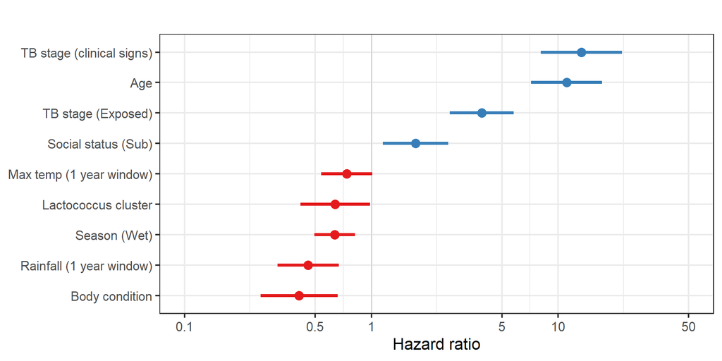

```r
sjPlot::plot_model(m_survival,
                   axis.lim = c(0.1,20),
                   vline.color = "darkgrey",
                   sort.est = T,
                   axis.labels = labels,
                   dot.size= 4,
                   line.size = 1.5,
                   show.p = T)+
  theme_bw(base_size = 16)+ggtitle("")+ylab("Hazard ratio")
```

This chunk took 67.98 minutes